# AI 에이전트를 위한 컨텍스트 엔지니어링: 메모리 vs. 컴팩션 vs. 도구 결과 정리

## 들어가며

장기 실행 에이전트를 만들 때 흔히 부딪히는 난제가 컨텍스트 관리입니다. 도구 결과, 모델 자신의 추론, 사용자 메시지가 모두 쌓이다 보면 결국 토큰 한도에 부딪히거나, 더는 도움이 되지 않는 컨텍스트에 비용을 치르게 됩니다. 건초더미에서 바늘 찾기 방식의 벤치마크 연구를 통해 [컨텍스트 부패(context rot)](https://research.trychroma.com/context-rot)라는 개념이 밝혀졌습니다. 컨텍스트 윈도의 토큰 수가 늘어날수록 모델이 그 컨텍스트에서 정보를 정확히 떠올리는 능력이 떨어진다는 것입니다. 즉 하드 컨텍스트 한도에 도달하기 전부터 에이전트는 토큰 하나당 얻는 것이 줄어들고 있을 수 있습니다.

[AI 에이전트를 위한 효과적인 컨텍스트 엔지니어링](https://www.anthropic.com/engineering/effective-context-engineering-for-ai-agents) 엔지니어링 블로그는 이를 자원 문제로 규정합니다. 컨텍스트는 유한하고 한계 수익이 체감하므로, 핵심 역량은 원하는 결과가 나올 가능성을 극대화하는 최소한의 고신호 토큰 집합을 찾아내는 것입니다. 이를 위한 지렛대는 여럿 있습니다. 자신만의 컨텍스트에서 작업을 격리하는 서브에이전트, 큰 결과를 아예 윈도에 들이지 않는 프로그래매틱 도구 호출 등입니다.

이 쿡북은 그중 세 가지, **컴팩션**, **도구 결과 정리**, **메모리**에 집중합니다. 셋 다 효과적인 컨텍스트 엔지니어링 전략이지만, 모두 서로 다른 방식으로 컨텍스트 윈도를 효율화하기 때문에 구분하기가 쉽지 않습니다. 이 차이를 이해해야 각 도구를 실제로 도움이 되는 작업 영역에 제대로 배치할 수 있습니다. 서브에이전트 활용 같은 다른 핵심 전략과 더불어, 이 세 가지는 장기 실행 에이전트를 만드는 팀이라면 반드시 이해해야 할 요소입니다. 세 가지 모두 퍼스트파티 API 지원이 있어서, 오케스트레이션 인프라를 직접 구축하지 않고도 도입할 수 있습니다.

- **컴팩션**은 컨텍스트 윈도의 내용을 고충실도 요약으로 압축해, 대화가 길어져도 성능 저하를 최소화하며 에이전트가 작업을 이어 갈 수 있게 합니다.
- **도구 결과 정리**는 도구 사용 자체에서 오는 비대화를 다룹니다. 에이전트가 도구를 불러 호출할수록 결과가 쌓이고, 그 도구 출력을 얼마나 남길지 결정하는 일이 컨텍스트 관리에서 점점 중요해집니다. 정리는 다시 가져올 수 있는 오래된 결과를 버리되, 호출이 있었다는 기록은 남깁니다.
- **메모리**는 구조화된 메모 작성입니다. 에이전트가 영속적인 외부 저장소에 기록해 두고, 모든 것을 활성 컨텍스트에 담아 두지 않고도 작업과 세션을 넘나들며 진행 상황을 추적합니다.

[Claude Code](https://claude.com/product/claude-code)는 이 전략들을 실제 프로덕션에서 여럿 사용합니다. 긴 대화에는 컴팩션을, 세션 간 지속에는 두 가지 상호 보완적인 메모리 시스템을 씁니다. Anthropic API는 셋 모두에 대해 퍼스트파티 구현을 제공합니다. [서버 측 컴팩션](https://platform.claude.com/docs/en/build-with-claude/compaction), [컨텍스트 편집](https://platform.claude.com/docs/en/build-with-claude/context-editing)(도구 결과 정리 포함), [메모리 도구](https://platform.claude.com/docs/en/agents-and-tools/tool-use/memory-tool)입니다. 이 쿡북에서는 이들을 어떻게 설계에 녹여 넣을지 다룹니다. 각각이 언제 적용되는지, 어떻게 설정하는지, 따로 쓸 때와 함께 쓸 때 무엇이 달라지는지, 어떤 조합이 어떤 사례에 맞는지를 살펴봅니다.

예제는 **장기 실행 리서치 에이전트**를 중심으로 합니다. 문서 모음을 읽고, 메모를 남기고, 여러 세션에 걸쳐 발견한 내용을 쌓아 가는 에이전트입니다. 세 가지 문제를 모두 자연스럽게 마주하기 때문에 좋은 시험대가 됩니다. 부피가 큰 문서 읽기(정리), 긴 분석 대화(컴팩션), 세션을 넘어 살아남아야 하는 지식(메모리)이 그것입니다.

### 배울 내용

- 파일 읽기나 API 응답처럼 다시 가져올 수 있는 큰 도구 결과가 컨텍스트를 지배할 때 `clear_tool_uses`로 **세션 내 토큰 증가를 억제**하는 방법
- 서버 측 컴팩션으로 **긴 대화를 계속 이어 가는** 방법. `compaction` 블록을 다시 직렬화하는 방법과 요약 이후 무엇이 살아남는지 확인하는 방법 포함
- 모델이 스스로 운용하는 파일 기반 메모리 핸들러를 구현해 **세션을 넘어 에이전트의 지식을 유지**하고, 세션 2가 세션 1이 멈춘 지점에서 이어 가게 하는 방법
- **각 기능을 가장 효과적으로 구현하는 방법**. 에이전트에 필요한 내용이 보존되도록 기본 컴팩션 프롬프트를 교체하고, `/memories`에 무엇을 쓸지 안내하고, 자신의 워크로드의 도구 사용 패턴에 맞춰 정리 설정을 시험하는 방법
- **내 워크로드가 실제로 겪는 컨텍스트 문제가 무엇인지 진단하고** 그에 맞는 기능을 고르는 방법. 워크로드 특성을 알맞은 도구에 대응시키는 프레임워크 포함

### 사전 준비

이 노트북을 실행하려면 다음이 필요합니다.

- **Anthropic API 키**를 환경 변수 또는 `.env` 파일의 `ANTHROPIC_API_KEY`로 설정 ([여기서 발급](https://platform.claude.com/))
- **Python 3.11 이상**과 `anthropic`, `python-dotenv`, `matplotlib` 패키지
- 이 노트북과 같은 위치의 **`research_corpus.py`**(저장소에 포함되어 있습니다). 노화 연구용 모델 생물에 관한 합성 리뷰 문서 8개(각 약 40K 토큰, 총 약 320K 토큰)를 담은 딕셔너리 `CORPUS`와, 컴팩션 이후 무엇이 살아남는지 확인하는 데 쓰는 프로브 질문들을 정의합니다. 이 딕셔너리를 교체해 여러분의 문서를 넣을 수도 있습니다.

> **쿡북 저장소에서 실행하시나요?** 노트북을 실행하기 전에 작업 디렉터리가 `tool_use/context_engineering`인지 확인하세요.

## 0단계: 환경 설정

이 디렉터리에 Anthropic API 키를 담은 `.env` 파일을 만드세요:

```
ANTHROPIC_API_KEY=your-key-here
```

```python
%%capture
%pip install anthropic python-dotenv matplotlib
```

```python
import json
import os
import tempfile
from collections import namedtuple
from pathlib import Path

import anthropic
import matplotlib.pyplot as plt
from dotenv import load_dotenv

load_dotenv()

if not os.environ.get("ANTHROPIC_API_KEY"):
    raise ValueError("ANTHROPIC_API_KEY not set. Add it to a .env file or export it.")

CORPUS_PATH = Path("research_corpus.py")
assert CORPUS_PATH.exists(), (
    f"research_corpus.py not found in {Path.cwd()}. It should be alongside this notebook."
)

client = anthropic.Anthropic()
MODEL = "claude-sonnet-4-6"
print(f"anthropic SDK {anthropic.__version__}, model {MODEL}")
```

```
anthropic SDK 0.84.0, model claude-sonnet-4-6
```

```python
# Force-reload the corpus module in case this kernel has a stale cached version
import importlib

import research_corpus

importlib.reload(research_corpus)
from research_corpus import COMPACTION_PROBES, CORPUS

# Count tokens via the API (cached in-memory so repeat kernel runs are fast).
_token_cache: dict[str, int] = {}


def count_tokens(text: str) -> int:
    if text not in _token_cache:
        _token_cache[text] = client.messages.count_tokens(
            model=MODEL, messages=[{"role": "user", "content": text}]
        ).input_tokens
    return _token_cache[text]


print(f"CORPUS is a dict of {len(CORPUS)} synthetic documents held in Python memory.")
print("When the agent calls read_file, the content is served from this dict and")
print("lands directly in the agent's context window — no disk I/O involved.\n")
_total_tokens = 0
for path, content in CORPUS.items():
    n_tok = count_tokens(content)
    _total_tokens += n_tok
    # Strip the virtual directory prefix for display clarity
    display_name = path.removeprefix("/research/")
    print(f"  {display_name:<26} ~{n_tok:>6,} tokens")
print(f"\n  Total corpus: ~{_total_tokens:,} tokens")

# Sanity check: the corpus should be large enough to push context well past
# 200K in a single read-pass. If this fires, research_corpus.py may be stale.
assert _total_tokens > 250_000, (
    f"Corpus is only {_total_tokens:,} tokens; expected >250K. "
    "Restart the kernel and re-run, or verify research_corpus.py is current."
)
```

```
CORPUS is a dict of 8 synthetic documents held in Python memory.
When the agent calls read_file, the content is served from this dict and
lands directly in the agent's context window — no disk I/O involved.

  celegans_review.md         ~41,260 tokens
  drosophila_review.md       ~41,200 tokens
  mouse_review.md            ~41,155 tokens
  zebrafish_review.md        ~41,095 tokens
  killifish_review.md        ~41,115 tokens
  yeast_review.md            ~41,101 tokens
  nmr_review.md              ~41,017 tokens
  rhesus_review.md           ~41,012 tokens

  Total corpus: ~328,955 tokens
```

## 문제: 장기 실행 리서치 에이전트

이 쿡북의 에이전트는 노화와 장수 연구용 모델 생물에 대한 비교 리뷰를 작성하는 생물학 연구자 역할을 맡습니다. 충분히 현실적인 과제입니다. 생물별 리뷰 문서를 두루 읽고, 비교 가능한 사실(수명, 유전적 조작 용이성, 인간에 대한 적용 가능성)을 뽑아내고, 구조화된 메모를 남기고, 읽은 내용 전반을 종합해야 합니다.

### 리서치 과제

에이전트가 받은 구체적인 지시는 이렇습니다. `/research/`에 있는 모델 생물들을 세 가지 차원(수명과 실험 처리량, 유전적 조작 용이성, 인간 노화에 대한 적용 가능성)에서 비교하되, 리뷰 문서 8개를 두 묶음으로 읽으며 메모를 남기고, 마지막에 비교 종합을 작성하라는 것입니다.

## 세 가지 API가 문제와 어떻게 대응되는가

각 API는 서로 다른 종류의 컨텍스트 증가를 겨냥합니다. 지금 어떤 종류를 마주하고 있는지 파악하는 것이 알맞은 도구를 고르는 첫걸음입니다.

### 개념적으로

**컴팩션**은 컨텍스트 윈도 한도에 가까워진 대화의 내용을 요약하고, 그 요약으로 다시 시작하는 기법입니다. 컨텍스트 윈도를 고충실도로 압축해 에이전트가 성능 저하를 최소화하며 계속 나아가게 하는 것이 목표입니다. 컴팩션의 묘미는 무엇을 남기고 무엇을 버리느냐에 있습니다. 지나치게 공격적인 컴팩션은 나중에야 중요성이 드러나는 미묘하지만 결정적인 맥락을 잃을 수 있습니다. 요약은 아키텍처 결정, 미해결 질문, 핵심 사실을 보존하고 중복 내용을 버립니다. 설계상 손실이 있지만, 도구 결과만이 아니라 모든 컨텍스트 증가를 다룹니다. 컴팩션은 *전체 대화 기록*에 대한 연산입니다. 사용자 메시지, 어시스턴트 메시지, 도구 호출, 도구 결과, 심지어 이전 컴팩션 블록까지 모두 요약 하나로 눌러 담습니다.

반면 **도구 결과 정리**는 *대화 기록의 일부*에 대한 연산입니다. 메시지 목록을 훑으며 `tool_result` 콘텐츠 블록만 외과적으로 교체하고, 사용자 메시지·어시스턴트 추론·`tool_use` 기록 등 나머지는 건드리지 않습니다. 에이전트가 도구를 호출하면 그 결과가 대화 기록의 일부가 되어 이후 모든 턴에서 컨텍스트 예산을 차지합니다. 그 내용 상당수는 다시 가져올 수 있습니다. 에이전트가 다시 읽을 수 있는 파일 내용, 다시 요청할 수 있는 API 응답 같은 것들이죠. 정리는 오래된 `tool_result` 블록을 짧은 자리표시자로 바꾸고, `tool_use` 기록은 남겨 두어 모델이 그 호출을 했다는 사실은 계속 알게 하되 부피가 큰 본문은 버립니다. 메시지 기록 깊숙한 곳에서 이미 호출된 도구의 원시 결과를 에이전트가 다시 볼 일은 드물기 때문에, 정리는 그 공간을 되찾는 가장 안전하고 가벼운 방법 중 하나입니다. 정말 데이터가 필요하면 도구를 다시 호출하면 됩니다.

**메모리**, 즉 구조화된 메모 작성은 에이전트가 컨텍스트 윈도 바깥에 지속되는 메모를 꾸준히 남기고 나중에 다시 불러들이는 기법입니다. 최소한의 부담으로 영속적 기억을 제공합니다. 에이전트가 복잡한 작업 전반에서 진행 상황을 추적하며, 수십 번의 도구 호출이나 컨텍스트 초기화를 거치면 사라졌을 핵심 맥락을 유지합니다. 초기화 이후(새 세션이나 컴팩션 이후) 에이전트는 자신의 메모를 읽고 이어 갑니다. 저장 백엔드는 여러분이 구현하므로, 무엇을 얼마나 오래 저장할지는 여러분이 통제합니다.

이 기능들을 켜는 것을 넘어, 어떻게 하면 가장 효과적으로 구현할지도 중요합니다. 기본 동작만으로 시작할 수는 있지만, 컴팩션 요약의 품질과 메모리에 남는 내용의 유용성은 모두 여러분이 제공하는 안내에 달려 있습니다. 아래 각 기능 절에는 효과적인 구현에 대한 하위 절이 포함되어 있습니다.

### 실무적으로

| API | 식별자 | 베타 헤더 | 촉발 조건 | 조정 가능한 항목 |
| --- | --- | --- | --- | --- |
| 컴팩션 | `compact_20260112` | `compact-2026-01-12` | 토큰 임계치(서버 측, 최소 50K) | `trigger`(기본 150K), `instructions`, `pause_after_compaction` |
| 도구 정리 | `clear_tool_uses_20250919` | `context-management-2025-06-27` | 토큰 임계치(서버 측) | `trigger`(기본 100K), `keep`(기본 도구 사용 3건), `clear_at_least`, `exclude_tools`, `clear_tool_inputs` |
| 메모리 도구 | `memory_20250818` | 없음(독립) | 모델(도구 호출임) | 클라이언트가 구현: `view`, `create`, `str_replace`, `insert`, `delete`, `rename` |

### 리서치 에이전트에 대응시키면

이 리서치 에이전트에 한정하면 세 문제가 깔끔하게 대응됩니다.

- 에이전트의 진행 코멘트("예쁜꼬마선충은 수명 18일에 유전체 전역 RNAi가 가능하고, 생쥐는 30개월이지만 코호트당 10만 달러가 든다...")와 사용자의 후속 질문이 긴 대화로 쌓입니다. **컴팩션** 문제입니다.
- 약 40K 토큰짜리 리뷰 문서 8개를 읽으면 도구 결과만 대략 320K 토큰이 되어, 컨텍스트 부패로 모델 성능이 떨어지는 구간에 확실히 들어섭니다. 그 대부분은 필요할 때 다시 읽으면 됩니다. **정리** 문제입니다.
- 작업이 여러 세션에 걸칩니다. 세션 1에서 킬리피시가 가장 수명이 짧은 척추동물(4~6개월)이라고 밝혀냈다면, 세션 2가 그 발견을 처음부터 다시 알아내는 대신 이어받아 쌓아 가기를 바랍니다. **메모리** 문제입니다.

우선순위를 잡는 대략적인 머릿속 모형은 이렇습니다. 컴팩션은 윈도가 너무 커졌을 때 전체를 압축하고, 정리는 윈도 안에서 다시 가져올 수 있는 낡은 데이터를 버리며, 메모리는 정보를 윈도 바깥으로 옮겨 세션을 넘어 살아남게 합니다. 층을 더할 때마다 조정할 설정과 이해해야 할 상호작용이 늘어나므로, 실제로 관찰되는 병목에 맞는 것부터 시작하는 편이 좋습니다.

## 리서치 에이전트

각 기능을 살펴보기 전에 에이전트 자체를 준비합니다. 도구 스키마, 도구 실행, 그리고 컨텍스트 관리 설정을 넣거나 빼고 실행할 수 있는 에이전트 루프입니다. 전체 루프를 볼 수 있도록 모두 인라인으로 작성했습니다.

```python
# ── Tool schemas ─────────────────────────────────────────────────────────
RESEARCH_TASK = """Compare the model organisms in /research/ on three dimensions:
1. Lifespan and experimental throughput (how fast can you get a lifespan result?)
2. Genetic tractability (what tools exist for manipulation and screening?)
3. Translational relevance (how well do findings transfer to human aging?)

Work through the organisms in two batches, recording a note after each
batch before moving on:

BATCH 1 (high-throughput models): Read celegans_review.md,
drosophila_review.md, yeast_review.md, and killifish_review.md. Record a
single detailed note covering all four organisms on all three dimensions.
Do not begin Batch 2 until this note is recorded.

BATCH 2 (low-throughput models): Read mouse_review.md,
zebrafish_review.md, nmr_review.md, and rhesus_review.md. Record a
single detailed note covering all four organisms on all three
dimensions.

After both batches, write a comprehensive comparative synthesis
contrasting the high-throughput and low-throughput models."""

BASE_TOOLS: list[dict] = [
    {
        "name": "search_files",
        "description": "Search document filenames and contents for a keyword. Returns matching paths with a short excerpt.",
        "input_schema": {
            "type": "object",
            "properties": {"query": {"type": "string", "description": "Search term"}},
            "required": ["query"],
        },
    },
    {
        "name": "read_file",
        "description": "Read the full content of a document by path.",
        "input_schema": {
            "type": "object",
            "properties": {
                "path": {"type": "string", "description": "e.g. /research/celegans_review.md"}
            },
            "required": ["path"],
        },
    },
    {
        "name": "record_finding",
        "description": "Record a research finding (freeform text). Findings are held for the duration of this session only; they are not persisted across sessions.",
        "input_schema": {
            "type": "object",
            "properties": {"finding": {"type": "string"}},
            "required": ["finding"],
        },
    },
]

# The memory tool spec is defined here but only added to the agent's tool
# list when a memory_handler is passed to run_research_session. Baseline
# and clearing/compaction runs do NOT get the memory tool.
MEMORY_TOOL_SPEC = {"type": "memory_20250818", "name": "memory"}

SYSTEM_PROMPT = """You are a biology research analyst writing a comparative review of model organisms for aging research.

Work systematically: search and read review documents, take notes on key facts (lifespans, genetic tools, translational strengths and caveats), and build a comparative picture.

Be concise in your reasoning text; the goal is notes, not essays."""
```

```python
# ── Tool execution ───────────────────────────────────────────────────────
def execute_research_tool(name: str, tool_input: dict, notes: list[str]) -> str:
    if name == "search_files":
        query = tool_input.get("query", "").lower()
        if not query:
            return "Error: query is required."
        hits: list[str] = []
        for path, content in CORPUS.items():
            if query in path.lower() or query in content.lower():
                for line in content.split("\n"):
                    if query in line.lower():
                        hits.append(f"  {path}\n    → {line.strip()[:120]}")
                        break
                else:
                    hits.append(f"  {path}")
        return (
            f"Found {len(hits)} match(es):\n" + "\n".join(hits)
            if hits
            else f"No matches for '{query}'."
        )

    if name == "read_file":
        path = tool_input.get("path", "")
        content = CORPUS.get(path)
        if content is None:
            return f"Error: '{path}' not found. Available: {', '.join(CORPUS.keys())}"
        return content

    if name == "record_finding":
        finding = tool_input.get("finding", "")
        notes.append(finding)
        return f"Finding #{len(notes)} recorded (session-local)."

    return f"Error: unknown tool '{name}'"
```

```python
# ── Session result container ─────────────────────────────────────────────
SessionResult = namedtuple(
    "SessionResult",
    [
        "messages",  # final message list
        "notes",  # notes taken this session
        "token_trajectory",  # list of (turn, total_context_tokens)
        "events",  # list of dicts describing compaction / clearing events
        "tool_counts",  # dict of tool_name -> call count
        "file_reads",  # list of (turn, path) for each read_file call
        "hit_limit",  # True if the session stopped because it hit the context window
        "final_text",  # final assistant text (convenience)
    ],
)


def _format_tool_arg(name: str, tool_input: dict) -> str:
    """Human-readable one-line summary of a tool call's arguments for verbose output."""
    if name == "search_files":
        return repr(tool_input.get("query", ""))
    if name == "read_file":
        return tool_input.get("path", "?")
    if name == "record_finding":
        finding = tool_input.get("finding", "")
        preview = finding[:50].replace("\n", " ")
        return f'"{preview}{"..." if len(finding) > 50 else ""}"'
    if name == "memory":
        cmd = tool_input.get("command", "?")
        path = tool_input.get("path", tool_input.get("old_path", ""))
        return f"{cmd} {path}"
    return str(tool_input)[:60]


# ── Agent loop ───────────────────────────────────────────────────────────
def run_research_session(
    initial_prompt: str,
    *,
    context_management: dict | None = None,
    betas: list[str] | None = None,
    memory_handler=None,
    max_turns: int = 12,
    label: str = "session",
    verbose: bool = True,
) -> SessionResult:
    """Run the research agent. Catches context-window overflow gracefully."""
    tools = list(BASE_TOOLS)
    if memory_handler is not None:
        tools.append(MEMORY_TOOL_SPEC)

    messages: list[dict] = [{"role": "user", "content": initial_prompt}]
    notes: list[str] = []
    token_trajectory: list[tuple[int, int]] = []
    events: list[dict] = []
    tool_counts: dict[str, int] = {}
    file_reads: list[tuple[int, str]] = []  # (turn, path) for each read_file
    hit_limit = False
    final_text = ""

    if verbose:
        print(f"┌─ [{label}]")

    for turn in range(1, max_turns + 1):
        kwargs: dict = dict(
            model=MODEL,
            max_tokens=4096,
            system=SYSTEM_PROMPT,
            tools=tools,
            messages=messages,
        )
        if context_management:
            kwargs["context_management"] = context_management
        if betas:
            kwargs["betas"] = betas

        # Call the API; catch context-window overflow
        try:
            if betas:
                response = client.beta.messages.create(**kwargs)
            else:
                response = client.messages.create(**kwargs)
        except anthropic.BadRequestError as e:
            # Context window exceeded (or similar input-too-large error)
            hit_limit = True
            if verbose:
                print(f"│  ⚠ CONTEXT WINDOW LIMIT REACHED at turn {turn} (API rejected)")
                print(f"│    {str(e)[:200]}")
            break

        # Track TOTAL context size: uncached + cache-read + cache-created.
        # usage.input_tokens alone excludes cached tokens, which makes the
        # plot show dips that are just cache hits, not context management.
        u = response.usage
        total_in = (
            u.input_tokens
            + (getattr(u, "cache_read_input_tokens", None) or 0)
            + (getattr(u, "cache_creation_input_tokens", None) or 0)
        )
        token_trajectory.append((turn, total_in))

        # Surface context-management events on their own prominent lines
        cm = getattr(response, "context_management", None)
        if cm is not None and getattr(cm, "applied_edits", None):
            for edit in cm.applied_edits:
                cleared_uses = getattr(edit, "cleared_tool_uses", None)
                cleared_toks = getattr(edit, "cleared_input_tokens", None)
                events.append(
                    {
                        "turn": turn,
                        "kind": "clearing",
                        "cleared_tool_uses": cleared_uses,
                        "cleared_input_tokens": cleared_toks,
                    }
                )
                if verbose:
                    print(
                        f"│  ✂ CLEARING (turn {turn}): {cleared_uses or '?'} tool results cleared, "
                        f"~{cleared_toks:,} tokens freed"
                        if cleared_toks
                        else f"│  ✂ CLEARING (turn {turn}): applied"
                    )

        # Serialize assistant content, track tool calls and compaction
        serialized: list[dict] = []
        tool_calls: list[dict] = []
        turn_tool_calls: list[tuple[str, dict]] = []  # (name, input) for verbose display
        compaction_this_turn = False
        for block in response.content:
            if block.type == "text":
                serialized.append({"type": "text", "text": block.text})
                if block.text.strip():
                    final_text = block.text
            elif block.type == "tool_use":
                serialized.append(
                    {
                        "type": "tool_use",
                        "id": block.id,
                        "name": block.name,
                        "input": block.input,
                    }
                )
                tool_calls.append({"id": block.id, "name": block.name, "input": block.input})
                turn_tool_calls.append((block.name, block.input))
                tool_counts[block.name] = tool_counts.get(block.name, 0) + 1
                # Track file reads specifically so we can show what clearing drops
                if block.name == "read_file":
                    file_reads.append((turn, block.input.get("path", "?")))
            elif block.type == "thinking":
                serialized.append(
                    {"type": "thinking", "thinking": block.thinking, "signature": block.signature}
                )
            elif block.type == "compaction":
                serialized.append({"type": "compaction", "content": block.content})
                events.append({"turn": turn, "kind": "compaction", "summary": block.content})
                compaction_this_turn = True
                if verbose:
                    print(
                        f"│  ⊟ COMPACTION (turn {turn}): "
                        f"~{count_tokens(block.content):,}-token summary replaces prior turns"
                    )
        messages.append({"role": "assistant", "content": serialized})
```

```python
        if not tool_calls:
            if verbose and not compaction_this_turn:
                print(f"│  turn {turn:2d}  ctx={total_in:>7,}  (final answer)")
            break

        # Execute tools, collecting result sizes so the verbose print
        # can show how much each call added to context
        tool_results: list[dict] = []
        result_sizes: list[int] = []
        for call in tool_calls:
            if call["name"] == "memory" and memory_handler is not None:
                result = memory_handler.handle(call["input"])
            else:
                result = execute_research_tool(call["name"], call["input"], notes)
            tool_results.append(
                {
                    "type": "tool_result",
                    "tool_use_id": call["id"],
                    "content": result,
                }
            )
            result_sizes.append(len(result) if isinstance(result, str) else 0)
        messages.append({"role": "user", "content": tool_results})

        if verbose and not compaction_this_turn:
            # Header with context size, then one line per tool call with
            # its argument and approximate result size (so you can see
            # which calls are responsible for the next turn's ctx jump)
            print(f"│  turn {turn:2d}  ctx={total_in:>7,}")
            for (name, tinput), rsize in zip(turn_tool_calls, result_sizes, strict=False):
                size_note = f"  → ~{rsize // 4:,} tok" if rsize > 200 else ""
                print(f"│            {name:<16} {_format_tool_arg(name, tinput)}{size_note}")

    if verbose:
        if token_trajectory:
            peak = max(t for _, t in token_trajectory)
            status = "⚠ HIT CONTEXT LIMIT" if hit_limit else "completed"
            print(
                f"└─ {status}: {len(token_trajectory)} turns, peak ctx {peak:,}, "
                f"final ctx {token_trajectory[-1][1]:,}, {len(events)} context event(s)\n"
            )
        else:
            print("└─ HIT CONTEXT LIMIT on first turn: 0 turns completed\n")

    return SessionResult(
        messages, notes, token_trajectory, events, tool_counts, file_reads, hit_limit, final_text
    )


def show_cleared_reads(result: SessionResult, keep: int):
    """Show which file reads are no longer in context after clearing.

    Clearing replaces tool results older than the last `keep` tool uses
    with placeholders. We reconstruct the tool-use order and mark any
    read that falls outside the surviving `keep`-window as cleared.

    Note: if clearing fires multiple times, only the last event's
    boundary is considered and earlier cleared-then-re-read files may
    be misclassified.
    """
    if not result.file_reads:
        print("No file reads in this session.")
        return
    clearing_events = [e for e in result.events if e["kind"] == "clearing"]
    if not clearing_events:
        print("Clearing never fired; all file reads remain in context.")
        return

    # Walk messages in order to reconstruct the sequence of tool_use blocks
    # and which turn each one came from. The last `keep` of these survive
    # the most recent clearing; earlier ones are cleared.
    tool_use_seq: list[tuple[int, str, str]] = []  # (turn, name, path-if-read)
    turn = 0
    for msg in result.messages:
        if msg["role"] == "assistant" and isinstance(msg["content"], list):
            turn += 1
            for block in msg["content"]:
                if block.get("type") == "tool_use":
                    name = block.get("name", "?")
                    path = block.get("input", {}).get("path", "") if name == "read_file" else ""
                    tool_use_seq.append((turn, name, path))

    last_clear_turn = clearing_events[-1]["turn"]
    seq_before = [t for t in tool_use_seq if t[0] < last_clear_turn]
    cleared_reads = [(t, p) for (t, n, p) in seq_before[:-keep] if n == "read_file"]
    surviving_reads = [
        (t, p) for tu in seq_before[-keep:] for (t, n, p) in [tu] if n == "read_file"
    ]
    # Reads at or after the last clearing turn are untouched by it.
    surviving_reads += [
        (t, p) for (t, n, p) in tool_use_seq if t >= last_clear_turn and n == "read_file"
    ]

    total = len(result.file_reads)
    print(f"Total file reads across session: {total}")
    print(f"Last clearing event fired at turn {last_clear_turn} (keep={keep})")
    print(f"\nReads cleared from context: {len(cleared_reads)}")
    for turn, path in cleared_reads[:12]:
        print(f"  ✗ turn {turn:2d}: {path}")
    if len(cleared_reads) > 12:
        print(f"  ... and {len(cleared_reads) - 12} more")
    print(
        f"\nReads still in context (within the keep={keep} window or after "
        f"the last clearing): {len(surviving_reads)}"
    )
    for turn, path in surviving_reads[:6]:
        print(f"  ✓ turn {turn:2d}: {path}")
    if len(surviving_reads) > 6:
        print(f"  ... and {len(surviving_reads) - 6} more")


# ── Plot helpers ─────────────────────────────────────────────────────────


def plot_trajectories(
    results: dict[str, SessionResult],
    title: str = "Context size per turn",
    triggers: dict[str, int] | None = None,
    project_growth_for: str | None = None,
):
    """Line plot of context tokens per turn.

    Vertical dashed lines mark turns where clearing fired; dash-dot lines
    mark compaction. Horizontal dotted lines mark configured trigger
    thresholds (pass triggers={"clearing": 20000, "compaction": 50000} etc).

    project_growth_for: label of a run to extrapolate. Fits a line to the
    last 5 points and draws a dotted segment forward ~8 turns to show where
    unmanaged growth is heading.
    """
    fig, ax = plt.subplots(figsize=(10, 4.5))
    colors = plt.rcParams["axes.prop_cycle"].by_key()["color"]

    for i, (label, res) in enumerate(results.items()):
        turns = [t for t, _ in res.token_trajectory]
        tokens = [tok for _, tok in res.token_trajectory]
        color = colors[i % len(colors)]
        ax.plot(turns, tokens, marker="o", label=label, markersize=4, color=color)
        # Mark events on the x-axis
        for ev in res.events:
            style = "--" if ev["kind"] == "clearing" else "-."
            ax.axvline(x=ev["turn"], color=color, linestyle=style, alpha=0.25, linewidth=1)
        # Dotted growth projection for the named run, capped at 1M
        if label == project_growth_for and len(turns) >= 3:
            HARD_LIMIT = 1_000_000
            fit_n = min(5, len(turns))
            xs, ys = turns[-fit_n:], tokens[-fit_n:]
            n = len(xs)
            sx, sy = sum(xs), sum(ys)
            slope = (n * sum(x * y for x, y in zip(xs, ys, strict=False)) - sx * sy) / (
                n * sum(x * x for x in xs) - sx * sx
            )
            intercept = (sy - slope * sx) / n
            proj_x, proj_y = [], []
            for x in range(turns[-1], turns[-1] + 9):
                y = slope * x + intercept
                if y > HARD_LIMIT:
                    # Clip the last segment to the 1M ceiling and stop
                    if proj_y and slope > 0:
                        proj_x.append(proj_x[-1] + (HARD_LIMIT - proj_y[-1]) / slope)
                        proj_y.append(HARD_LIMIT)
                    break
                proj_x.append(x)
                proj_y.append(y)
            if proj_y:
                ax.plot(proj_x, proj_y, linestyle=":", color=color, alpha=0.6, linewidth=1.5)
```

```python
    # Horizontal reference lines for trigger thresholds
    if triggers:
        for name, value in triggers.items():
            ax.axhline(y=value, color="gray", linestyle=":", alpha=0.6, linewidth=1)
            ax.annotate(
                f"{name} trigger: {value:,}",
                xy=(ax.get_xlim()[1], value),
                xytext=(-5, 3),
                textcoords="offset points",
                ha="right",
                va="bottom",
                fontsize=8,
                color="gray",
            )

    # 200K reference: earlier models cap here and would hard-stop
    if ax.get_ylim()[1] > 30_000:
        ax.axhline(y=200_000, color="gray", linestyle="--", alpha=0.5, linewidth=1)
        ax.annotate(
            "200K: earlier models stop here",
            xy=(ax.get_xlim()[0], 200_000),
            xytext=(5, -12),
            textcoords="offset points",
            ha="left",
            va="top",
            fontsize=8,
            color="gray",
            alpha=0.8,
        )

    ax.set_xlabel("Turn")
    ax.set_ylabel("Context tokens (incl. cached)")
    ax.set_title(title)
    ax.legend(loc="best")
    ax.grid(alpha=0.3)
    plt.tight_layout()
    plt.show()


def plot_summary_bars(results: dict[str, SessionResult], title: str = "Session outcomes"):
    """Side-by-side bars: final context, file reads."""
    labels = list(results.keys())
    final_ctx = [r.token_trajectory[-1][1] for r in results.values()]
    reads = [r.tool_counts.get("read_file", 0) for r in results.values()]

    fig, axes = plt.subplots(1, 2, figsize=(9, 3.5))
    fig.suptitle(title, y=1.02)

    for ax, values, ylabel in zip(
        axes,
        [final_ctx, reads],
        ["Final context (tokens)", "File reads"],
        strict=False,
    ):
        bars = ax.bar(range(len(labels)), values, color=plt.cm.Set2(range(len(labels))))
        ax.set_ylabel(ylabel)
        ax.set_xticks(range(len(labels)))
        ax.set_xticklabels(labels, rotation=30, ha="right", fontsize=8)
        ax.grid(axis="y", alpha=0.3)
        for bar, val in zip(bars, values, strict=False):
            ax.text(
                bar.get_x() + bar.get_width() / 2,
                bar.get_height(),
                f"{val:,}" if val > 1000 else str(val),
                ha="center",
                va="bottom",
                fontsize=7,
            )

    plt.tight_layout()
    plt.show()
```

### 기준점: 컨텍스트 관리 없음

먼저 컨텍스트 관리 설정 없이 에이전트를 실행합니다. 문서 하나가 부록 표까지 포함해 약 40K 토큰인 큰 코퍼스이므로 컨텍스트가 빠르게 쌓입니다. 같은 실행을 두 관점에서 살펴보겠습니다. 1M 토큰 윈도에서 벌어지는 일과, 200K 윈도였다면 벌어졌을 일입니다.

#### 1부: 1M 토큰 윈도에서

Claude Sonnet 4.6과 Claude Opus 4.6은 모두 [1M 토큰 컨텍스트 윈도](https://platform.claude.com/docs/en/build-with-claude/context-windows)를 제공합니다. 이 과제에서는 기준점 실행의 총 입력이 그 한도 아래에 머무릅니다. 에이전트가 코퍼스 전체를 읽고 벽에 부딪히지 않은 채 종합을 마칩니다. 아래 궤적은 실행이 수십만 토큰까지 올라가는 모습을 보여 주며, 점선은 같은 속도로 계속 증가할 경우를 나타냅니다.

```
┌─ [baseline]
│  turn  1  ctx=  1,058
│            read_file        /research/celegans_review.md  → ~27,465 tok
│            read_file        /research/drosophila_review.md  → ~27,435 tok
│            read_file        /research/yeast_review.md  → ~27,320 tok
│            read_file        /research/killifish_review.md  → ~27,349 tok
│  turn  2  ctx=166,043
│            record_finding   "## BATCH 1 NOTES: High-Throughput Model Organisms ..."
│  turn  3  ctx=168,242
│            read_file        /research/mouse_review.md  → ~27,390 tok
│            read_file        /research/zebrafish_review.md  → ~27,363 tok
│            read_file        /research/nmr_review.md  → ~27,287 tok
│            read_file        /research/rhesus_review.md  → ~27,285 tok
│  turn  4  ctx=332,821
│            record_finding   "## BATCH 2 NOTES: Low-Throughput Model Organisms —..."
│  turn  5  ctx=335,279  (final answer)
└─ completed: 5 turns, peak ctx 335,279, final ctx 335,279, 0 context event(s)
```

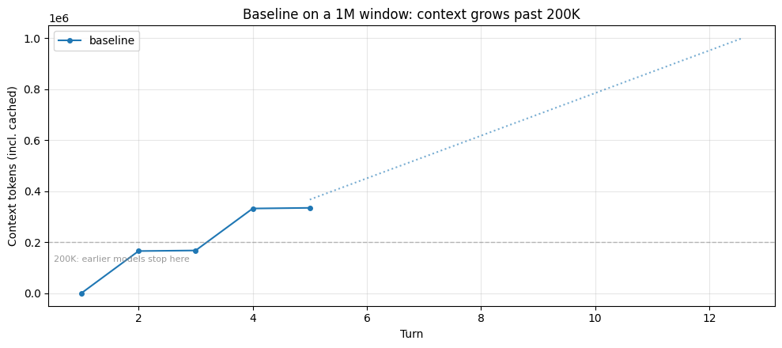

```
Peak context: 335,279 tokens across 5 turns
File reads: 8, Notes: 2

The run stayed within the 1M window. The dotted line projects where continued growth at the same rate would land, capped at 1M.
```

```python
baseline = run_research_session(RESEARCH_TASK, label="baseline", max_turns=12)

plot_trajectories(
    {"baseline": baseline},
    "Baseline on a 1M window: context grows past 200K",
    project_growth_for="baseline",
)

peak = max(t for _, t in baseline.token_trajectory)
n_turns = len(baseline.token_trajectory)
print(f"Peak context: {peak:,} tokens across {n_turns} turns")
print(f"File reads: {baseline.tool_counts.get('read_file', 0)}, Notes: {len(baseline.notes)}")
if baseline.hit_limit:
    print("\n⚠ This run hit the 1M hard limit.")
else:
    print(
        "\nThe run stayed within the 1M window. The dotted line projects "
        "where continued growth at the same rate would land, capped at 1M."
    )
```

```python
# ── What's actually sitting in the context window at the end of the run ──
# Walk the message list and bucket everything by type. This is what the
# model has to attend to on every turn: no hard wall stopped it, but the
# pile keeps growing and every fact from early turns is buried deeper.


def _bucket_context(messages: list[dict]) -> dict[str, tuple[int, int]]:
    """Categorize message content into (count, approx_tokens) per bucket."""
    buckets: dict[str, list[int]] = {
        "File-read results": [],
        "Other tool results": [],
        "Agent reasoning text": [],
        "Tool-call records": [],
        "User/task prompts": [],
    }
    for msg in messages:
        content = msg.get("content")
        if isinstance(content, str):
            buckets["User/task prompts"].append(len(content))
        elif isinstance(content, list):
            for block in content:
                bt = block.get("type")
                if bt == "tool_result":
                    body = block.get("content", "")
                    body = body if isinstance(body, str) else json.dumps(body)
                    # Heuristic: large tool results are file reads
                    key = "File-read results" if len(body) > 5000 else "Other tool results"
                    buckets[key].append(len(body))
                elif bt == "text":
                    buckets["Agent reasoning text"].append(len(block.get("text", "")))
                elif bt == "tool_use":
                    buckets["Tool-call records"].append(len(json.dumps(block.get("input", {}))))
    # chars // 4 as a rough token estimate; the exact number isn't the point
    return {k: (len(v), sum(v) // 4) for k, v in buckets.items() if v}


print("=" * 72)
print("WHAT THE MODEL IS ATTENDING TO at the end of the baseline run")
print("=" * 72)
breakdown = _bucket_context(baseline.messages)
total_est = sum(tok for _, tok in breakdown.values())
# Scale the char-based estimates so the total matches the API's reported
# context size. This keeps the proportions meaningful and the absolute
# numbers consistent with the usage figures shown elsewhere.
api_total = baseline.token_trajectory[-1][1]
scale = api_total / total_est if total_est else 1.0
print(f"\nContext breakdown ({api_total:,} tokens total per API usage):\n")
for label, (count, tokens) in sorted(breakdown.items(), key=lambda kv: -kv[1][1]):
    scaled = int(tokens * scale)
    pct = 100 * tokens / total_est if total_est else 0
    print(f"  {label:<26} ~{scaled:>8,} tokens  ({count:>3} blocks, {pct:4.1f}%)")

if baseline.file_reads:
    first_turn, first_path = baseline.file_reads[0]
    doc_name = first_path.split("/")[-1]
    print(f"\nFirst document read: {doc_name} at turn {first_turn}.")
```

```
========================================================================
WHAT THE MODEL IS ATTENDING TO at the end of the baseline run
========================================================================

Context breakdown (335,279 tokens total per API usage):

  File-read results          ~ 322,946 tokens  (  8 blocks, 96.3%)
  Tool-call records          ~   6,287 tokens  ( 10 blocks,  1.9%)
  Agent reasoning text       ~   5,660 tokens  (  5 blocks,  1.7%)
  User/task prompts          ~     357 tokens  (  1 blocks,  0.1%)
  Other tool results         ~      26 tokens  (  2 blocks,  0.0%)

First document read: celegans_review.md at turn 1.
```

위 분해 결과가 그 규모를 구체적으로 보여 줍니다. 모델은 매 턴마다 수십만 토큰 분량의 파일 내용을 지고 갑니다. 대부분은 에이전트가 이미 처리하고 메모까지 남긴 문서들입니다. 첫 번째로 읽은 문서는 여전히 윈도 안에 있지만, 실행이 끝날 무렵에는 다른 도구 결과 수십만 토큰과 에이전트의 모든 추론·메모 뒤편에 놓여 있습니다. 제거된 것은 아니지만 다른 모든 것과 주의를 두고 경쟁하고 있는 셈이죠. 컨텍스트 부패가 나타나는 지점이 바로 여기입니다. 내용이 기술적으로는 존재하더라도, 윈도가 차오를수록 그 깊이에 있는 세부 사항의 회상 능력이 떨어집니다. 그리고 프리필 지연 시간은 컨텍스트 길이에 비례하므로, 매 턴마다 그 더미 전체를 처리하는 비용을 치릅니다.

#### 2부: 200K 토큰 윈도에서

이전 모델들은 200K 토큰이 상한입니다. 그런 모델에서는 같은 기준점 실행이 단단한 벽에 부딪힙니다. 컨텍스트가 한도를 넘는 순간 API가 다음 요청을 거부하고, 작업은 도중에 멈춥니다.

아래 셀은 기준점이 처음 200K를 넘은 턴을 찾아, 200K 모델의 관점에서 이 실행이 어떻게 보이는지 보여 줍니다. 그 지점까지는 같은 궤적이다가 그대로 멈춰 버립니다.

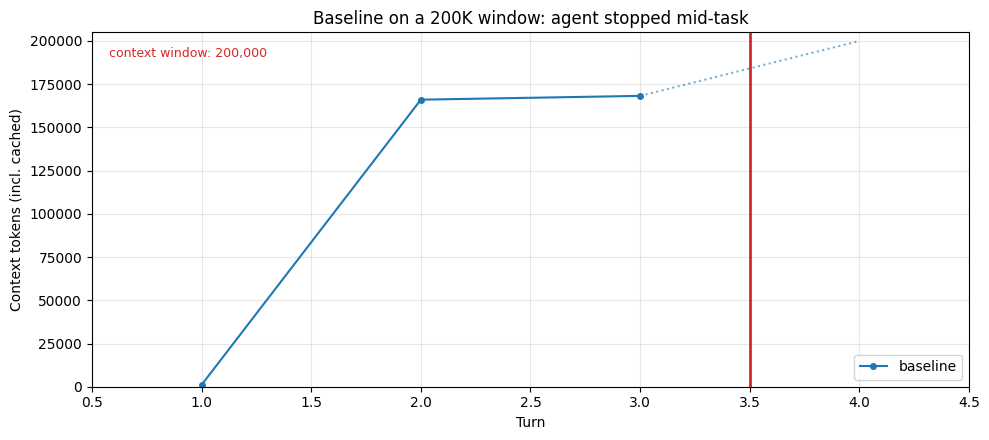

```
⚠ Baseline HIT THE CONTEXT WINDOW LIMIT.
  Completed 3 turns before the API rejected the next request.
  Last successful context: 168,242 tokens
  File reads attempted: 8
  Notes taken: 2

  The agent stopped mid-task. Without context management, it cannot continue past this point.
```

```python
# No new agent run here. We reuse the Part-1 baseline's token_trajectory
# and clip it at the turn where context first exceeded 200K, to show what
# the same run would look like from a 200K model's perspective.
cross_turn = next((t for t, tok in baseline.token_trajectory if tok > 200_000), None)

if cross_turn is None:
    print(
        "Baseline never exceeded 200K tokens this run; a 200K model "
        "would have seen the same result."
    )
else:
    # Plot the turns that fit under 200K, plus a dotted segment to the
    # rejected turn and a red cutoff marker between them.
    clipped_traj = [(t, tok) for t, tok in baseline.token_trajectory if t < cross_turn]
    turns_c = [t for t, _ in clipped_traj]
    toks_c = [tok for _, tok in clipped_traj]
    rejected_ctx = dict(baseline.token_trajectory).get(cross_turn, 200_000)

    fig, ax = plt.subplots(figsize=(10, 4.5))
    ax.plot(turns_c, toks_c, marker="o", markersize=4, label="baseline")
    # Dotted segment from last successful turn to the rejected turn
    ax.plot(
        [turns_c[-1], cross_turn],
        [toks_c[-1], min(rejected_ctx, 200_000)],
        linestyle=":",
        color="#1f77b4",
        alpha=0.6,
        linewidth=1.5,
    )
    # Hard red vertical line marking the cutoff between the last
    # successful turn and the rejected one
    cutoff_x = (turns_c[-1] + cross_turn) / 2
    ax.axvline(x=cutoff_x, color="#d62728", linewidth=2)
    ax.set_xlim(0.5, cross_turn + 0.5)
    ax.set_ylim(0, 205_000)
    ax.text(
        0.02,
        0.96,
        "context window: 200,000",
        transform=ax.transAxes,
        ha="left",
        va="top",
        fontsize=9,
        color="#d62728",
    )
    ax.set_xlabel("Turn")
    ax.set_ylabel("Context tokens (incl. cached)")
    ax.set_title("Baseline on a 200K window: agent stopped mid-task")
    ax.legend(loc="lower right")
    ax.grid(alpha=0.3)
    plt.tight_layout()
    plt.show()

    last_turn = clipped_traj[-1][0]
    last_ctx = clipped_traj[-1][1]
    reads_done = sum(1 for t, _ in baseline.file_reads if t < cross_turn)
    notes_at_stop = sum(
        1
        for m in baseline.messages[: 2 * cross_turn]
        if isinstance(m.get("content"), list)
        for b in m["content"]
        if b.get("type") == "tool_use" and b.get("name") == "record_finding"
    )
    print("⚠ Baseline HIT THE CONTEXT WINDOW LIMIT.")
    print(f"  Completed {last_turn} turns before the API rejected the next request.")
    print(f"  Last successful context: {last_ctx:,} tokens")
    print(f"  File reads attempted: {reads_done}")
    print(f"  Notes taken: {notes_at_stop}")
    print()
    print(
        "  The agent stopped mid-task. Without context management, it "
        "cannot continue past this point."
    )
```

두 실패 양상은 같은 근본 문제에서 나옵니다. 컨텍스트 윈도가 수십만 토큰의 파일 내용으로 가득 차는데, 대부분은 이미 처리하고 메모까지 남긴 것들입니다. 다른 것은 실패가 드러나는 방식뿐입니다. 200K 윈도에서는 단단한 정지입니다. API가 다음 요청을 거부하고 작업이 단계 도중에 끝납니다. 1M 윈도에서는 에이전트가 계속 돌아가지만, 윈도가 차오르며 컨텍스트 부패가 시작됩니다. 초기에 읽은 문서가 기술적으로는 남아 있어도 실행이 끝날 무렵에는 이후 읽은 모든 것에 파묻혀, 모델이 그 세부 사항을 회상하는 능력이 떨어집니다. 에이전트는 작업을 마치지만, 종합의 품질은 그 더미와 싸우는 회상 능력에 달리게 됩니다. 프리필 지연 시간도 함께 커집니다. 얼마나 쓸모 있는지와 무관하게 매 턴마다 전체 컨텍스트를 처리하는 비용을 치릅니다.

아래에서 다룰 기능들은 작업 집합을 충분히 작게 유지해 두 실패 양상 모두를 피합니다. 윈도가 차지 않으므로 작은 모델은 멈추지 않고 큰 모델은 성능이 떨어지지 않습니다. 그래프에는 200K 기준선을 점선으로 함께 표시해, 이전 모델이었다면 어디서 잘렸을지 볼 수 있게 했습니다.

## 컴팩션

[컴팩션](https://platform.claude.com/docs/en/build-with-claude/compaction)은 오래 이어지는 대화의 컨텍스트를 관리하는 유용한 전략입니다. 컨텍스트 윈도 한도에 가까워진 대화의 내용을 요약하고 그 요약으로 다시 시작합니다. 이는 에이전트 자신의 추론 텍스트, 사용자와 주고받은 대화, 세션 동안 내려진 결정들을 다룹니다. 이전 턴의 구체적인 행동 순서나 정확한 표현은 보존되지 않지만, 에이전트가 세운 목표와 결정, 주요 발견은 요약으로 남습니다. 요약이 무엇을 남길지는 여러분의 컴팩션 프롬프트에 달려 있으며, 이는 아래에서 다룹니다.

본질적으로 컴팩션은 컨텍스트 윈도의 내용을 고충실도로 압축해, 에이전트가 성능 저하를 최소화하며 계속 나아가게 합니다. 트레이드오프는 요약이 반드시 남겨야 할 것과 안전하게 버릴 수 있는 것을 고르는 데 있습니다. 지나치게 공격적인 컴팩션은 나중에야 중요성이 드러나는 미묘하지만 결정적인 맥락을 잃을 수 있습니다. 요약은 핵심 결정과 사실을 보존하지만 구체적인 수치나 정확한 표현은 버릴 수 있습니다. 요약 모델이 돌아가므로 추론 비용이 들지만, 도구 결과만이 아니라 모든 컨텍스트 증가를 다룹니다.

### 내부 동작 방식

컴팩션을 최소한으로 구현한 예시입니다. Anthropic의 퍼스트파티 API는 견고하고 검증된 버전(토큰 임계치에서 자동 촉발, 대화에 자연스럽게 들어가는 타입 지정 콘텐츠 블록, 올바른 도구 사용 짝 맞추기)을 제공하지만, 아래의 25줄 남짓한 버전이 그 메커니즘을 구체적으로 보여 줍니다. 대화를 텍스트로 렌더링하고, 모델에 요약을 요청하고, 기존 메시지를 그 요약으로 교체하는 것입니다.

```python
def demo_compact(client, messages: list[dict], model: str) -> list[dict]:
    """Summarize the conversation and return a fresh message list containing only the summary."""
    # Render to a plain-text transcript
    lines: list[str] = []
    for msg in messages:
        role = msg["role"]
        content = msg.get("content", "")
        if isinstance(content, str):
            lines.append(f"[{role}] {content}")
        elif isinstance(content, list):
            for block in content:
                bt = block.get("type", "?")
                if bt == "text":
                    lines.append(f"[{role}] {block['text']}")
                elif bt == "tool_use":
                    lines.append(f"[{role}→tool] {block['name']}({block.get('input', {})})")
                elif bt == "tool_result":
                    body = block.get("content", "")
                    body = body if isinstance(body, str) else json.dumps(body)
                    lines.append(f"[tool_result] {body[:200]}{'…' if len(body) > 200 else ''}")
    transcript = "\n".join(lines)

    resp = client.messages.create(
        model=model,
        max_tokens=1024,
        messages=[
            {
                "role": "user",
                "content": (
                    "Summarize the following agent transcript, preserving key "
                    "decisions, facts learned, and open threads. Be concise.\n\n"
                    f"<transcript>\n{transcript}\n</transcript>"
                ),
            }
        ],
    )
    summary = resp.content[0].text
    return [{"role": "user", "content": f"[conversation summary]\n{summary}"}]
```

```python
# Demonstrate on a longer synthetic conversation so the summary is meaningfully shorter
demo_convo = []
organisms = [
    (
        "C. elegans",
        "18-day median lifespan at 20°C. Survival curve takes 4-6 weeks. Automated platforms handle thousands of animals. Genome-wide RNAi by feeding, fast CRISPR knock-ins. ~40% human orthology, no adaptive immunity, post-mitotic soma.",
    ),
    (
        "Drosophila",
        "60-80 day median lifespan at 25°C. Survival curves take 3-4 months. GAL4/UAS tissue-specific expression, FLP/FRT mosaic analysis, mature CRISPR. ~60% human disease gene orthology. Good for cardiac aging and neurodegeneration models.",
    ),
    (
        "Mouse",
        "~24-30 month median lifespan. Full study is 3-year commitment, $1-2/day/animal, $100K+ per 100-mouse cohort. Cre-lox conditionals, inbred strain panels, humanized models. ~85% orthology, best translational predictor.",
    ),
    (
        "Killifish",
        "4-6 month median lifespan (GRZ strain), shortest-lived vertebrate in the lab. Survival curves under a year. CRISPR works, toolkit still thin. ~70% orthology. Rapid vertebrate aging phenotypes on a compressed timeline.",
    ),
    (
        "Yeast",
        "Replicative lifespan ~25 divisions, ~1-2 weeks to result. Genome-wide deletion collection, trivial CRISPR, pooled competitive assays. ~30% orthology. Great for mechanism, not for translation.",
    ),
    (
        "Naked mole-rat",
        "Max lifespan >37 years, negligible senescence. No controlled genetics (eusocial breeding). Cell-line studies only. Near-zero cancer incidence. Comparative biology resource, not a screening organism.",
    ),
]
for name, facts in organisms:
    demo_convo.append({"role": "user", "content": f"Tell me about {name} for aging research."})
    demo_convo.append({"role": "assistant", "content": f"{name}: {facts}"})
demo_convo.append({"role": "user", "content": "What are the key tradeoffs across all of these?"})
demo_convo.append(
    {
        "role": "assistant",
        "content": "The core tradeoff is throughput vs. translational relevance. Short-lived invertebrates (worm, fly, yeast) let you screen fast but translate weakly. Mouse is the translational gatekeeper but slow and expensive. Killifish tries to split the difference. The mole-rat is a comparative outlier you study to understand exceptional longevity, not to screen interventions.",
    }
)

before_tokens = count_tokens(json.dumps(demo_convo))
compacted = demo_compact(client, demo_convo, MODEL)
after_tokens = count_tokens(json.dumps(compacted))
print(
    f"Conversation size: ~{before_tokens:,} → ~{after_tokens:,} tokens "
    f"({(before_tokens - after_tokens) / before_tokens:.0%} reduction)"
    if after_tokens < before_tokens
    else f"Conversation size: ~{before_tokens:,} → ~{after_tokens:,} tokens"
)
print(f"\nSummary produced:\n{compacted[0]['content'][:800]}")
if len(compacted[0]["content"]) > 800:
    print("...")
```

```
Conversation size: ~741 → ~449 tokens (39% reduction)

Summary produced:
[conversation summary]
## Summary: Model Organisms for Aging Research

### Key Facts Learned
| Organism | Lifespan | Study Duration | Human Orthology | Standout Feature |
|---|---|---|---|---|
| *C. elegans* | 18-day median | 4–6 weeks | ~40% | Genome-wide RNAi; high throughput |
| *Drosophila* | 60–80 days | 3–4 months | ~60% | Tissue-specific genetics; cardiac/neuro models |
| Mouse | 24–30 months | ~3 years | ~85% | Best translational predictor; expensive ($100K+/cohort) |
| Killifish | 4–6 months | <1 year | ~70% | Shortest-lived vertebrate; thin toolkit |
| Yeast | ~25 divisions | 1–2 weeks | ~30% | Mechanistic screening; poor translation |
| Naked mole-rat | >37 years | N/A | — | Negligible senescence; no genetic control |

### Core Tradeoff
**Throughput ↔ Translational relevance** —
...
```

위 예시는 그 메커니즘을 보여 줍니다. 모델이 대화의 압축된 버전을 만들어 내고, 에이전트는 거기서부터 이어 갑니다.

### API 사용하기

Anthropic API는 이를 `compact_20260112` 컨텍스트 편집으로 기본 제공합니다. 토큰 임계치(최소 50K)에서 자동으로 촉발되고, 대화에 자연스럽게 들어가는 타입 지정 `compaction` 콘텐츠 블록을 반환하며, 요약 경계를 넘나드는 도구 사용 짝 맞추기를 처리합니다. 컴팩션이 일어나면 컴팩션 블록을 다시 직렬화해 보내고(`{"type": "compaction", "content": block.content}`), API는 다음 요청에서 그 이전의 모든 것을 버립니다.

**API 문서:** [Compaction — platform.claude.com](https://platform.claude.com/docs/en/build-with-claude/compaction)

다음은 컴팩션을 설정한 채 실행한 리서치 에이전트입니다. 트리거를 180K로 잡아 첫 묶음의 읽기(약 165K)가 그 아래에 머무르게 했습니다. 컴팩션 궤적은 그 묶음 동안 기준점을 따라가다가, 둘째 묶음이 컨텍스트를 트리거 너머로 밀어 올리면서 갈라집니다. 출력의 `⊟ COMPACTION` 줄과, 요약이 이전 대화를 대체하는 그래프상의 하강 지점을 눈여겨보세요.

```
┌─ [compaction]
│  turn  1  ctx=  1,129
│            read_file        /research/celegans_review.md  → ~27,465 tok
│            read_file        /research/drosophila_review.md  → ~27,435 tok
│            read_file        /research/yeast_review.md  → ~27,320 tok
│            read_file        /research/killifish_review.md  → ~27,349 tok
│  turn  2  ctx=166,103
│            record_finding   "## BATCH 1 DETAILED NOTE: High-Throughput Model Or..."
│  turn  3  ctx=169,164
│            read_file        /research/mouse_review.md  → ~27,390 tok
│            read_file        /research/zebrafish_review.md  → ~27,363 tok
│            read_file        /research/nmr_review.md  → ~27,287 tok
│            read_file        /research/rhesus_review.md  → ~27,285 tok
│  ⊟ COMPACTION (turn 4): ~2,783-token summary replaces prior turns
│  turn  5  ctx=  5,635
│            search_files     'comparative aging model organisms synthesis pipeline translational'
│  turn  6  ctx=  5,751
│            search_files     'aging model organism review'
│  turn  7  ctx=  5,829  (final answer)
└─ completed: 7 turns, peak ctx 169,164, final ctx 5,829, 1 context event(s)
```

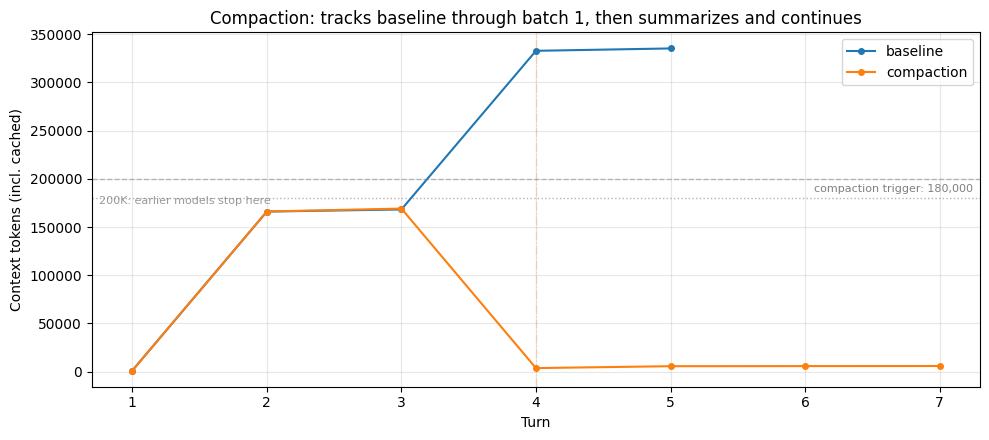

```
Baseline:    completed turn 5, peak 335,279 tokens
Compaction:  completed turn 7, peak 169,164 tokens, 1 compaction event(s)
  Compaction #1 at turn 4: ~2,783-token summary

→ Baseline climbed to 335,279 tokens; compaction kept the peak at 169,164. On a smaller context window the baseline would have been cut off mid-task; here it completed, but every turn paid to process the full pile.
```

```python
COMPACTION_TRIGGER = 180_000  # above batch-1's ~165K so the rise is visible before compaction fires

compaction_run = run_research_session(
    RESEARCH_TASK,
    betas=["compact-2026-01-12"],
    context_management={
        "edits": [
            {
                "type": "compact_20260112",
                "trigger": {"type": "input_tokens", "value": COMPACTION_TRIGGER},
            }
        ]
    },
    max_turns=12,
    label="compaction",
)

plot_trajectories(
    {"baseline": baseline, "compaction": compaction_run},
    "Compaction: tracks baseline through batch 1, then summarizes and continues",
    triggers={"compaction": COMPACTION_TRIGGER},
)

compaction_events = [e for e in compaction_run.events if e["kind"] == "compaction"]

# Outcome comparison
print(
    f"Baseline:    {'HIT LIMIT at' if baseline.hit_limit else 'completed'} "
    f"turn {len(baseline.token_trajectory)}, "
    f"peak {max(t for _, t in baseline.token_trajectory):,} tokens"
)
print(
    f"Compaction:  {'HIT LIMIT at' if compaction_run.hit_limit else 'completed'} "
    f"turn {len(compaction_run.token_trajectory)}, "
    f"peak {max(t for _, t in compaction_run.token_trajectory):,} tokens, "
    f"{len(compaction_events)} compaction event(s)"
)

if compaction_events:
    for i, ev in enumerate(compaction_events, 1):
        print(
            f"  Compaction #{i} at turn {ev['turn']}: ~{count_tokens(ev['summary']):,}-token summary"
        )

baseline_peak = max(t for _, t in baseline.token_trajectory)
compaction_peak = max(t for _, t in compaction_run.token_trajectory)
print(
    f"\n→ Baseline climbed to {baseline_peak:,} tokens; compaction kept "
    f"the peak at {compaction_peak:,}. On a smaller context window the "
    f"baseline would have been cut off mid-task; here it completed, but "
    f"every turn paid to process the full pile."
)
```

```python
# What compaction costs: check the summary text directly for a MIX of
# details. We inspect what the summary PRESERVED, not what the agent
# happens to have in context at end-of-run (which could include reads
# that happened after compaction fired).
compaction_events = [e for e in compaction_run.events if e["kind"] == "compaction"]

print("=" * 70)
print("WHAT COMPACTION COSTS: what the summary preserved vs. dropped")
print("=" * 70)

if not compaction_events:
    print("(Compaction did not fire this run; probe skipped)")
else:
    # Use the last compaction summary — it covers the most history.
    last_ev = compaction_events[-1]
    summary_text = last_ev["summary"]
    n_tok = count_tokens(summary_text)
    print(
        f"Last compaction at turn {last_ev['turn']} produced a "
        f"~{n_tok:,}-token summary. The file content read before "
        f"that point was distilled into this.\n"
    )
    print(
        "Checking the summary text directly for six details: three "
        "HIGH-LEVEL facts (central to the task, likely summarized) and "
        "three OBSCURE specifics (appendix table cells, unlikely to make "
        "the cut).\n"
    )

    results = []
    for question, answer_key, expected_survive in COMPACTION_PROBES:
        survived = answer_key.lower() in summary_text.lower()
        results.append((question, answer_key, expected_survive, survived))

    for label, expect in [
        ("HIGH-LEVEL FACTS (expected to survive)", True),
        ("OBSCURE SPECIFICS (expected to be lost)", False),
    ]:
        print(f"── {label} ──")
        for q, key, exp, surv in results:
            if exp != expect:
                continue
            status = "✓ in summary" if surv else "✗ not in summary"
            print(f"  {status:<18} looking for '{key}' — {q}")
        print()

    hl_survived = sum(1 for _, _, e, s in results if e and s)
    hl_total = sum(1 for _, _, e, _ in results if e)
    ob_survived = sum(1 for _, _, e, s in results if not e and s)
    ob_total = sum(1 for _, _, e, _ in results if not e)

    print("=" * 70)
    print(
        f"RESULT: high-level {hl_survived}/{hl_total} preserved, "
        f"obscure {ob_survived}/{ob_total} preserved"
    )
    print("=" * 70)

    # Show a representative excerpt of the summary so the reader can see
    # the compression directly.
    excerpt = summary_text.strip()
    if len(excerpt) > 600:
        excerpt = excerpt[:600] + "…"
    print("\nExcerpt from the summary (first ~600 chars):\n")
    for line in excerpt.splitlines():
        print(f"  {line}")
```

```
======================================================================
WHAT COMPACTION COSTS: what the summary preserved vs. dropped
======================================================================
Last compaction at turn 4 produced a ~2,783-token summary. The file content read before that point was distilled into this.

Checking the summary text directly for six details: three HIGH-LEVEL facts (central to the task, likely summarized) and three OBSCURE specifics (appendix table cells, unlikely to make the cut).

── HIGH-LEVEL FACTS (expected to survive) ──
  ✓ in summary       looking for '18' — What is the approximate median lifespan of C. elegans at 20°C?
  ✓ in summary       looking for 'killifish' — Which model organism is the shortest-lived vertebrate used in aging research?
  ✓ in summary       looking for '60' — Roughly what percentage of human disease genes have Drosophila orthologs?

── OBSCURE SPECIFICS (expected to be lost) ──
  ✗ not in summary   looking for '61' — In the appendix Table A5, what is the I-squared heterogeneity value for the NAD+ precursor intervention?
  ✗ not in summary   looking for '55' — In appendix Table A2, what was the effect magnitude for the IIS reduction intervention in cohort 2?
  ✗ not in summary   looking for '0.72' — In appendix Table A7, what is the PhenoAge-like epigenetic clock acceleration ratio under DR for liver tissue?

======================================================================
RESULT: high-level 3/3 preserved, obscure 0/3 preserved
======================================================================

Excerpt from the summary (first ~600 chars):

  ## Task Overview
  I am a biology research analyst writing a comparative review of model organisms for aging research. The task has three phases:
  1. **BATCH 1 (DONE):** Read and record a note on four high-throughput models (C. elegans, Drosophila, yeast, killifish)
  2. **BATCH 2 (IN PROGRESS):** Read four low-throughput models (mouse, zebrafish, NMR, rhesus) and record a single note — **FILES HAVE BEEN READ, NOTE NOT YET RECORDED**
  3. **FINAL:** Write a comprehensive comparative synthesis contrasting both batches

  ---

  ## Current State

  ### Batch 1 — COMPLETE
  - All four files read: `celegans_revi…
```

### 분석

기준점은 컨텍스트 윈도 한도에 부딪히거나(작은 윈도에서는 단단한 정지) 컨텍스트 부패가 회상 능력을 유의미하게 떨어뜨릴 만큼 토큰이 쌓일 때까지 계속 올라갑니다. 컴팩션은 두 가지를 모두 다룹니다. 컨텍스트가 트리거를 넘으면 이전 대화가 모델이 생성한 요약으로 대체되며 컨텍스트가 급격히 떨어집니다. 에이전트는 끝없이 커지는 윈도가 아니라 가벼운 윈도로 작업을 이어 갑니다.

위 프로브는 요약 텍스트에서 여러 *종류*의 세부 정보를 직접 확인합니다. 대체로 이런 양상이 나타납니다. 작업의 중심이 되는 상위 수준 사실(에이전트가 메모한 수명 수치, 생물 종, 주요 비교)은 대개 요약에 살아남습니다. 부록 표의 특정 칸 하나, 이질성 통계량 같은 지엽적인 사항은 대개 그렇지 않습니다. 이는 도구 결과 정리와의 의미 있는 차이입니다. 정리는 도구 결과를 *통째로* 버려서 다시 가져오기 전까지 그 내용이 사라지는 반면, 컴팩션은 *알맹이*를 압축된 형태로 남기되 문자 그대로의 세부는 잃습니다.

컴팩션이 주는 것은 윈도를 가볍게 유지하는 범용적인 수단입니다. 대화와 도구 결과를 함께 다루고, 중요한 내용은 요약된 형태로 살아남으며, 그렇지 않았다면 잘리거나 파묻혔을 상황에서도 에이전트가 계속 일합니다. 반대로 얻지 못하는 것은 구체적 사항에 대한 문자 그대로의 충실도, 그리고 세션 간 지속성입니다. 컨텍스트 비대화가 대부분 다시 가져올 수 있는 도구 출력 때문이라면 정리 쪽이 더 저렴하고 무손실입니다(에이전트가 도구를 다시 호출하면 됩니다). 다시 가져올 수 없는 대화와 추론이 원인이라면 컴팩션이 알맞습니다.

### 컴팩션을 효과적으로 구현하기

`instructions` 파라미터로 기본 요약 프롬프트를 통째로 교체할 수 있습니다. [컴팩션 문서](https://platform.claude.com/docs/en/build-with-claude/compaction#custom-summarization-instructions)에 기본 프롬프트가 그대로 실려 있습니다.

> You have written a partial transcript for the initial task above. Please write a summary of the transcript. The purpose of this summary is to provide continuity so you can continue to make progress towards solving the task in a future context, where the raw history above may not be accessible and will be replaced with this summary. Write down anything that would be helpful, including the state, next steps, learnings etc. You must wrap your summary in a `<summary></summary>` block.

출발점으로 삼기 좋습니다. 다만 커스텀 `instructions`는 이 프롬프트를 보완하는 것이 아니라 완전히 대체합니다. 따라서 직접 제공한다면 전체 틀을 여러분이 책임져야 합니다. 문서에 실린 코딩 맥락의 예시는 `"Focus on preserving code snippets, variable names, and technical decisions."`입니다.

이 쿡북의 리서치 에이전트라면, 위 프로브에서 유실 위험이 드러난 구체적 항목들을 짚어 이렇게 작성해 볼 수 있습니다:

```
context_management={
    "edits": [{
        "type": "compact_20260112",
        "trigger": {"type": "input_tokens", "value": 150_000},
        "instructions": (
            "Summarize this research agent transcript. Preserve every "
            "quantitative lifespan figure and effect size with its "
            "source organism, and note which documents have been read "
            "and which remain. Wrap the summary in <summary></summary>."
        ),
    }]
}
```

## 도구 결과 정리

에이전트가 도구를 호출하면 결과마다 `tool_result` 블록이 대화에 덧붙습니다([컨텍스트 편집 문서](https://platform.claude.com/docs/en/build-with-claude/context-editing)). 이 블록들은 에이전트가 내용을 처리하고 넘어간 뒤에도 이후 모든 턴에서 입력 토큰 예산을 차지합니다. 다시 호출할 수 있는 도구(파일 읽기, API 질의, 검색)라면 결과를 문자 그대로 계속 지고 갈 필요가 없는 경우가 많습니다. 필요하면 도구를 다시 호출하면 되니까요.

정리는 오래된 `tool_result` 블록을 짧은 자리표시자 문자열로 바꿉니다. 그 앞의 `tool_use` 블록은 남으므로 모델은 자신이 어떤 입력으로 호출을 했다는 기록은 유지하되, 부피가 큰 응답 본문은 사라집니다. 세 기능 중 가장 저렴합니다. 추론 비용 없이 메시지 목록에 대한 기계적 편집만 하면 됩니다.

### 내부 동작 방식

메커니즘을 구체적으로 보기 위해, 도구 결과 정리를 최소한으로 구현한 예시를 보겠습니다. 퍼스트파티 API는 자동 촉발, 올바른 블록 짝 맞추기 불변식, 도구 예외 처리 등을 갖춘 견고하고 검증된 버전을 제공하지만, 15줄 남짓한 이 버전을 보면 핵심 동작이 손에 잡힙니다. 메시지 목록을 훑어 `tool_result` 블록을 찾고, 가장 최근 몇 개를 제외한 나머지의 내용을 자리표시자로 바꾸는 것입니다.

```python
def demo_clear_tool_results(messages: list[dict], keep: int = 3) -> int:
    """Replace the content of all but the last `keep` tool_result blocks.
    Returns the number of blocks cleared."""
    positions: list[tuple[int, int]] = []
    for mi, msg in enumerate(messages):
        if msg.get("role") != "user" or not isinstance(msg.get("content"), list):
            continue
        for bi, block in enumerate(msg["content"]):
            if isinstance(block, dict) and block.get("type") == "tool_result":
                positions.append((mi, bi))

    to_clear = positions[:-keep] if keep > 0 else positions
    for mi, bi in to_clear:
        messages[mi]["content"][bi]["content"] = "[cleared to save context]"
    return len(to_clear)
```

```python
# Demonstrate on a small message list using the actual research corpus
sample_paths = list(CORPUS.keys())[:3]  # first three docs

demo = [{"role": "user", "content": "Read three files and summarize."}]
for i, path in enumerate(sample_paths):
    demo.append(
        {
            "role": "assistant",
            "content": [
                {"type": "tool_use", "id": f"t{i}", "name": "read_file", "input": {"path": path}},
            ],
        }
    )
    demo.append(
        {
            "role": "user",
            "content": [
                {"type": "tool_result", "tool_use_id": f"t{i}", "content": CORPUS[path]},
            ],
        }
    )

before_tokens = count_tokens(json.dumps(demo))
cleared = demo_clear_tool_results(demo, keep=1)
after_tokens = count_tokens(json.dumps(demo))

print(f"Cleared {cleared} of 3 tool results (keep=1 leaves the most recent)")
print(
    f"Message-list size: ~{before_tokens:,} → ~{after_tokens:,} tokens "
    f"({(before_tokens - after_tokens) / before_tokens:.0%} reduction)"
)
print()
print("What each tool_result looks like now:")
for _i, msg in enumerate(demo):
    if not isinstance(msg.get("content"), list):
        continue
    for block in msg["content"]:
        if block.get("type") == "tool_use":
            print(f"\n  [tool_use]  read_file({block['input']['path']})")
        elif block.get("type") == "tool_result":
            body = block["content"]
            if body == "[cleared to save context]":
                print(f"  [tool_result] {body!r}  (← cleared)")
            else:
                preview = body[:80].replace("\n", " ")
                print(f"  [tool_result] {preview!r}... (~{count_tokens(body):,} tokens retained)")
```

```
Cleared 2 of 3 tool results (keep=1 leaves the most recent)
Message-list size: ~128,740 → ~43,060 tokens (67% reduction)

What each tool_result looks like now:

  [tool_use]  read_file(/research/celegans_review.md)
  [tool_result] '[cleared to save context]'  (← cleared)

  [tool_use]  read_file(/research/drosophila_review.md)
  [tool_result] '[cleared to save context]'  (← cleared)

  [tool_use]  read_file(/research/mouse_review.md)
  [tool_result] '# Model Organism Review: Mus musculus in Aging Research  The laboratory mouse is'... (~41,155 tokens retained)
```

위 예시가 메커니즘을 보여 줍니다. 여기에 빠진 것은 토큰 집계와 자동 촉발, 올바른 `tool_use`/`tool_result` 짝 맞추기 불변식, 도구별 예외 처리, 그리고 정리가 일어났다는 사실을 모델 쪽에서 인지하게 하는 부분입니다.

### API 사용하기

Anthropic API는 이를 `clear_tool_uses_20250919` 컨텍스트 편집으로 기본 제공합니다. 토큰 집계와 촉발을 서버 측에서 처리하고, 블록 짝 맞추기를 보존하며, 특정 도구를 정리 대상에서 뺄 수 있게 해 줍니다(뒤에서 보겠지만 메모리 도구를 함께 쓸 때 유용합니다). 정리가 일어나면 응답에 `context_management.applied_edits`가 포함되어 몇 개의 도구 사용이 정리되고 몇 토큰이 확보되었는지 알려 줍니다.

> 확장 사고 블록을 위한 `clear_thinking_20251015`도 있습니다. 설정 형태는 같고 `type`만 다릅니다. 둘 다 사용한다면 `edits` 배열에서 이것이 첫 번째 항목이어야 합니다.

**API 문서:** [Context editing — platform.claude.com](https://platform.claude.com/docs/en/build-with-claude/context-editing)

다음은 정리를 켠 채 실행한 리서치 에이전트입니다. 기준점에서는 파일을 읽을 때마다 컨텍스트가 올라갔지만, 정리는 컨텍스트가 트리거를 넘을 때마다 오래된 도구 결과를 버려 이 실행을 일정 범위 안에 붙잡아 둡니다. 출력의 `✂ CLEARING` 줄을 눈여겨보세요. 그래프의 세로 점선이 각 촉발 시점을 표시합니다.

```
┌─ [clearing]
│  turn  1  ctx=  1,058
│            read_file        /research/celegans_review.md  → ~27,465 tok
│            read_file        /research/drosophila_review.md  → ~27,435 tok
│            read_file        /research/yeast_review.md  → ~27,320 tok
│            read_file        /research/killifish_review.md  → ~27,349 tok
│  turn  2  ctx=166,043
│            record_finding   "## BATCH 1 NOTES: High-Throughput Model Organisms ..."
│  turn  3  ctx=169,211
│            read_file        /research/mouse_review.md  → ~27,390 tok
│            read_file        /research/zebrafish_review.md  → ~27,363 tok
│            read_file        /research/nmr_review.md  → ~27,287 tok
│            read_file        /research/rhesus_review.md  → ~27,285 tok
│  ✂ CLEARING (turn 4): 4 tool results cleared, ~163,817 tokens freed
│  turn  4  ctx=169,174
│            record_finding   ""
│  ✂ CLEARING (turn 5): 4 tool results cleared, ~163,811 tokens freed
│  turn  5  ctx=169,255
│            record_finding   ""
│  ✂ CLEARING (turn 6): 4 tool results cleared, ~163,807 tokens freed
│  turn  6  ctx=169,313
│            record_finding   "## BATCH 2 NOTES: Low-Throughput Model Organisms (..."
│  ✂ CLEARING (turn 7): 4 tool results cleared, ~162,930 tokens freed
│  turn  7  ctx=173,137  (final answer)
└─ completed: 7 turns, peak ctx 173,137, final ctx 173,137, 4 context event(s)
```

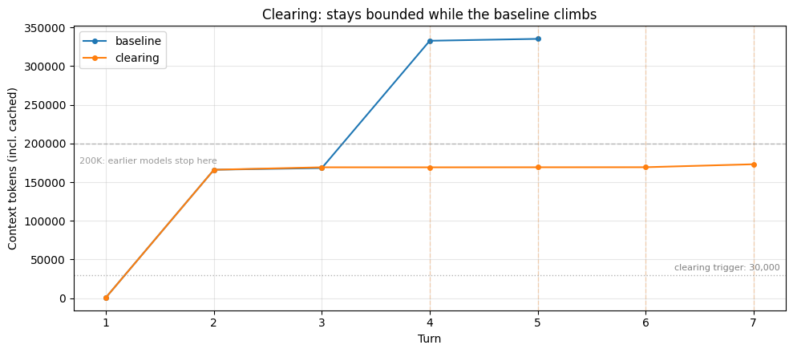

```
Baseline:  completed turn 5, peak 335,279 tokens
Clearing:  completed turn 7, peak 173,137 tokens

→ Baseline climbed to 335,279 tokens; clearing kept the peak at 173,137. On a smaller context window the baseline would have been cut off; here both completed, but the baseline was attending to far more on every turn.

Clearing events: 4
File reads: baseline=8, clearing=8
```

```python
CLEARING_KEEP = 4  # How many most-recent tool results survive each clearing

clearing_run = run_research_session(
    RESEARCH_TASK,
    betas=["context-management-2025-06-27"],
    context_management={
        "edits": [
            {
                "type": "clear_tool_uses_20250919",
                "trigger": {"type": "input_tokens", "value": 30_000},
                "keep": {"type": "tool_uses", "value": CLEARING_KEEP},
                "clear_at_least": {"type": "input_tokens", "value": 10_000},
            }
        ]
    },
    label="clearing",
    max_turns=12,
)

plot_trajectories(
    {"baseline": baseline, "clearing": clearing_run},
    "Clearing: stays bounded while the baseline climbs",
    triggers={"clearing": 30_000},
)

# Show outcome comparison
baseline_turns = len(baseline.token_trajectory)
clearing_turns = len(clearing_run.token_trajectory)
print(
    f"Baseline:  {'HIT LIMIT at' if baseline.hit_limit else 'completed'} "
    f"turn {baseline_turns}, peak {max(t for _, t in baseline.token_trajectory):,} tokens"
)
print(
    f"Clearing:  {'HIT LIMIT at' if clearing_run.hit_limit else 'completed'} "
    f"turn {clearing_turns}, peak {max(t for _, t in clearing_run.token_trajectory):,} tokens"
)

baseline_peak = max(t for _, t in baseline.token_trajectory)
clearing_peak = max(t for _, t in clearing_run.token_trajectory)
print(
    f"\n→ Baseline climbed to {baseline_peak:,} tokens; clearing kept "
    f"the peak at {clearing_peak:,}. On a smaller context window the "
    f"baseline would have been cut off; here both completed, but the "
    f"baseline was attending to far more on every turn."
)

print(f"\nClearing events: {len([e for e in clearing_run.events if e['kind'] == 'clearing'])}")
print(
    f"File reads: baseline={baseline.tool_counts.get('read_file', 0)}, "
    f"clearing={clearing_run.tool_counts.get('read_file', 0)}"
)
```

```python
# What's lost: which file reads are no longer in the clearing run's context?
print("=" * 60)
print("WHAT CLEARING COSTS: reads no longer in context")
print("=" * 60)
show_cleared_reads(clearing_run, keep=CLEARING_KEEP)
print(
    "\nThe cleared reads above are gone from the conversation. If the "
    "agent needs that content again, it must call read_file again; the "
    "information is re-fetchable, but the original read is no longer "
    "visible in context."
)
```

```
============================================================
WHAT CLEARING COSTS: reads no longer in context
============================================================
Total file reads across session: 8
Last clearing event fired at turn 7 (keep=4)

Reads cleared from context: 7
  ✗ turn  1: /research/celegans_review.md
  ✗ turn  1: /research/drosophila_review.md
  ✗ turn  1: /research/yeast_review.md
  ✗ turn  1: /research/killifish_review.md
  ✗ turn  3: /research/mouse_review.md
  ✗ turn  3: /research/zebrafish_review.md
  ✗ turn  3: /research/nmr_review.md

Reads still in context (within the keep=4 window or after the last clearing): 1
  ✓ turn  3: /research/rhesus_review.md

The cleared reads above are gone from the conversation. If the agent needs that content again, it must call read_file again; the information is re-fetchable, but the original read is no longer visible in context.
```

### 분석

위 두 번째 셀은 그 대가를 보여 줍니다. 가장 최근 몇 개를 제외한 모든 파일 읽기가 컨텍스트에서 사라졌습니다. 종합 단계에 이르면 에이전트에는 두 가지 선택지가 있습니다. 자신의 메모와 마지막 정리에서 살아남은 최근 읽기만으로 작업할 수 있습니다. 메모가 충실했다면 괜찮지만, 부실했다면 에이전트가 보긴 했으나 기록하지 않은 세부 사항을 놓치게 됩니다. 아니면 `read_file`을 다시 호출해 정리된 내용을 다시 가져올 수 있습니다. 이 경우 정리 실행이 같은 문서에 대해 기준점보다 파일 읽기 횟수가 많아질 수 있습니다. 에이전트가 다 쓰기 전에 정리된 읽기가 있기 때문입니다. 두 번째 경로의 비용은 도구에 따라 다릅니다. 로컬 파일을 다시 읽는 것은 거의 공짜지만, 호출 제한이 있거나 느린 API를 다시 호출하는 것은 그렇지 않습니다. `keep`과 `trigger`를 조정하면 에이전트가 이 둘 사이 어디에 놓일지가 달라집니다.

정리가 주는 것은 추론 비용 없이 범위가 묶인 윈도이며, 하드 한도로 인한 중단과 컨텍스트 누적에 따른 회상 저하를 모두 피할 수 있습니다. 반대로 얻지 못하는 것은 도구 결과가 아닌 내용(에이전트 자신의 추론, 사용자 메시지)에 대한 도움과 세션 간 지속성입니다.

### 정리를 효과적으로 구현하기

컴팩션이나 메모리와 달리 정리에는 다듬을 프롬프트가 없고, 조정 항목은 모두 수치(`trigger`, `keep`, `clear_at_least`)이거나 목록(`exclude_tools`)입니다. 이해해 둘 트레이드오프가 하나 있습니다. 정리는 캐싱된 프롬프트 접두부를 무효화합니다. 이를 감안해 캐시 무효화가 그만한 값을 하도록 충분한 토큰을 정리하세요. `clear_at_least` 파라미터가 매번 최소 몇 토큰을 정리할지 보장해 줍니다. 정리가 일어날 때마다 캐시 쓰기 비용이 발생하지만, 이후 요청은 새로 캐싱된 접두부를 재사용할 수 있습니다.

`trigger`와 `keep`의 적정값은 에이전트가 도구 결과를 어떻게 쓰는지에 달려 있습니다. 결과가 얼마나 큰지, 에이전트가 얼마나 자주 되짚어 보는지, 다시 가져오는 비용이 싼지가 기준입니다. 위 정리 실행은 trigger=30K, keep=4를 썼고, 뒤에 나오는 세 기능 동시 실행은 정리와 컴팩션이 일을 나눠 갖도록 더 높은 트리거와 keep=6을 씁니다. 여러분의 에이전트 워크로드로 몇 가지 설정을 시험해 보세요. 응답마다 담기는 `context_management.applied_edits` 필드가 몇 개의 도구 사용과 몇 토큰이 정리되었는지 보여 주므로 각 설정의 효과를 직접 관찰할 수 있습니다.

## 메모리 도구

[메모리 도구](https://platform.claude.com/docs/en/agents-and-tools/tool-use/memory-tool)는 메모리 파일 디렉터리를 통해 Claude가 대화를 넘나들며 정보를 저장하고 불러올 수 있게 합니다. Claude는 세션 사이에 유지되는 파일을 만들고, 읽고, 수정하고, 삭제할 수 있어서, 모든 것을 컨텍스트 윈도에 담아 두지 않고도 시간에 걸쳐 지식을 쌓아 갈 수 있습니다.

이것이 적시(just-in-time) 컨텍스트 검색의 핵심 기능입니다. 관련 정보를 미리 전부 적재하는 대신, 에이전트가 배운 것을 메모리에 저장해 두었다가 필요할 때 불러옵니다. 덕분에 활성 컨텍스트는 지금 관련 있는 것에 집중할 수 있는데, 이는 모든 것을 한꺼번에 적재하면 윈도가 감당하지 못하는 장기 워크플로에서 결정적입니다. 정리와 컴팩션은 둘 다 현재 컨텍스트에 대해 작동하므로, 새 세션이 시작되어 윈도가 비어 있을 때는 아무 도움이 되지 않습니다. 메모리가 그 문제를 해결합니다.

메모리 도구는 클라이언트 측에서 동작합니다. Claude가 메모리 작업을 수행하는 도구 호출을 하면 여러분의 애플리케이션이 그 작업을 로컬에서 실행합니다. 데이터를 어디에 어떻게 저장할지 완전히 통제할 수 있다는 뜻입니다. API는 도구 프로토콜을 제공하고 메모리 확인 동작을 규정하는 시스템 프롬프트를 자동 주입합니다. 저장 백엔드는 여러분이 구현합니다.

### 내부 동작 방식

최소 구현 예시입니다. 세션이 끝나면 쓰고 다음 세션 전에 읽는 키-값 저장소입니다. 퍼스트파티 API는 견고한 버전(모델이 추론 과정에서 무엇을 언제 저장할지 스스로 결정, 완전한 파일 작업, 프로토콜 프롬프트 자동 주입)을 제공하지만, 10줄 남짓한 이 버전이 핵심 패턴을 구체적으로 보여 줍니다.

```python
class SimpleMemoryStore:
    def __init__(self):
        self._store: dict[str, str] = {}

    def save(self, key: str, value: str) -> None:
        self._store[key] = value

    def load(self, key: str) -> str | None:
        return self._store.get(key)

    def keys(self) -> list[str]:
        return list(self._store)


# Demonstrate the pattern manually
store = SimpleMemoryStore()
store.save(
    "lifespans",
    "C. elegans: ~18 days. Mouse: ~24-30 months. Killifish: 4-6 months (shortest vertebrate).",
)
store.save(
    "tractability",
    "Worm has genome-wide RNAi by feeding. Mouse has Cre-lox conditionals. Killifish toolkit still thin.",
)

# In "session 2", you'd inject these into the first prompt:
preamble = "\n".join(f"- {k}: {store.load(k)}" for k in store.keys())
print(f"Session-2 opening prompt would include:\n\nPrior research notes:\n{preamble}")
```

```
Session-2 opening prompt would include:

Prior research notes:
- lifespans: C. elegans: ~18 days. Mouse: ~24-30 months. Killifish: 4-6 months (shortest vertebrate).
- tractability: Worm has genome-wide RNAi by feeding. Mouse has Cre-lox conditionals. Killifish toolkit still thin.
```

위 예시가 패턴을 보여 주긴 하지만, 무엇을 저장하고 언제 불러올지 결정하는 일을 여러분에게 떠맡깁니다. 사실 그것은 모델이 더 잘할 수 있는 일입니다. 모델은 추론 도중에 어떤 사실이 중요한지, 언제 그것을 떠올려야 하는지 알고 있으니까요.

### API 사용하기

Anthropic API는 이를 `memory_20250818` 도구로 기본 제공합니다. 모델이 도구 사용 루프의 일부로 무엇을 언제 저장할지 결정하고, 자동 주입되는 시스템 프롬프트가 프로토콜("무엇보다 먼저 항상 메모리 디렉터리를 확인하라")을 규정하며, 키-값이 아니라 완전한 파일 작업을 제공합니다. 클라이언트 측 도구이므로 API는 프로토콜을 제공하고 파일 백엔드는 여러분이 구현합니다.

**API 문서:** [Memory tool — platform.claude.com](https://platform.claude.com/docs/en/agents-and-tools/tool-use/memory-tool)

여섯 가지 명령을 모두 구현한 완전한 핸들러입니다.

```python
class MemoryToolHandler:
    """Client-side backend for the memory_20250818 tool.
    Implements view, create, str_replace, insert, delete, rename.
    File-backed (tempdir) so writes persist across notebook cells.
    """

    def __init__(self, base_dir: str | None = None):
        self.base = Path(base_dir or tempfile.mkdtemp(prefix="memory_"))
        self.base.mkdir(parents=True, exist_ok=True)

    def _resolve(self, path: str) -> Path:
        rel = path.removeprefix("/memories").removeprefix("/") or "."
        resolved = (self.base / rel).resolve()
        if not str(resolved).startswith(str(self.base.resolve())):
            raise ValueError(f"path escapes memory directory: {path}")
        return resolved

    def handle(self, tool_input: dict) -> str:
        cmd = tool_input.get("command")
        try:
            if cmd == "view":
                return self._view(tool_input.get("path", "/memories"))
            if cmd == "create":
                return self._create(tool_input["path"], tool_input["file_text"])
            if cmd == "str_replace":
                return self._str_replace(
                    tool_input["path"], tool_input["old_str"], tool_input["new_str"]
                )
            if cmd == "insert":
                return self._insert(
                    tool_input["path"], tool_input["insert_line"], tool_input["insert_text"]
                )
            if cmd == "delete":
                return self._delete(tool_input["path"])
            if cmd == "rename":
                return self._rename(tool_input["old_path"], tool_input["new_path"])
            return f"Error: unknown command '{cmd}'"
        except Exception as e:
            return f"Error: {e}"

    def _view(self, path: str) -> str:
        p = self._resolve(path)
        if not p.exists():
            return (
                "Directory /memories is empty."
                if path in ("/memories", "/memories/")
                else f"Error: '{path}' does not exist."
            )
        if p.is_dir():
            entries = sorted(p.iterdir())
            if not entries:
                return "(empty directory)"
            return "\n".join((f"{e.name}/" if e.is_dir() else e.name) for e in entries)
        content = p.read_text()
        lines = content.split("\n")
        return "\n".join(f"{i + 1:4d}\t{line}" for i, line in enumerate(lines))

    def _create(self, path: str, file_text: str) -> str:
        p = self._resolve(path)
        p.parent.mkdir(parents=True, exist_ok=True)
        p.write_text(file_text)
        return f"Created {path}"

    def _str_replace(self, path: str, old_str: str, new_str: str) -> str:
        p = self._resolve(path)
        content = p.read_text()
        if old_str not in content:
            return f"Error: old_str not found in {path}"
        if content.count(old_str) > 1:
            return f"Error: old_str appears {content.count(old_str)} times; be more specific."
        p.write_text(content.replace(old_str, new_str, 1))
        return f"Replaced in {path}"

    def _insert(self, path: str, insert_line: int, insert_text: str) -> str:
        p = self._resolve(path)
        lines = p.read_text().split("\n")
        lines.insert(insert_line, insert_text)
        p.write_text("\n".join(lines))
        return f"Inserted at line {insert_line} in {path}"

    def _delete(self, path: str) -> str:
        p = self._resolve(path)
        if p.is_dir():
            import shutil

            shutil.rmtree(p)
        else:
            p.unlink()
        return f"Deleted {path}"

    def _rename(self, old_path: str, new_path: str) -> str:
        old_p, new_p = self._resolve(old_path), self._resolve(new_path)
        new_p.parent.mkdir(parents=True, exist_ok=True)
        old_p.rename(new_p)
        return f"Renamed {old_path} → {new_path}"
```

> 보안 참고: `_resolve` 메서드는 경로 탐색(`../../etc/passwd`)을 방어합니다. 프로덕션에서는 파일 크기와 디렉터리 전체 크기에도 상한을 두는 것이 좋습니다. 더 깊은 메모리 패턴은 [Memory Cookbook](https://platform.claude.com/cookbook/tool-use-memory-cookbook)을 참고하세요.

### 이점 확인하기

효과를 구체적으로 보기 위해 에이전트를 세 세션에 걸쳐 실행합니다.

1. **세션 1**은 초기 리서치를 수행하고 그 결과를 `/memories`에 기록합니다.
2. **세션 2(메모리 없음)**는 메모리 디렉터리가 빈 상태로 후속 작업을 수행합니다. 모든 것을 처음부터 다시 알아내야 합니다.
3. **세션 2(메모리 있음)**는 같은 후속 작업을 수행하되 세션 1이 저장한 파일에 접근할 수 있습니다. 먼저 그 파일을 읽고, 다시 조사하는 대신 그 위에 쌓아 갑니다.

메모리의 이점은 이 두 세션 2 실행을 비교할 때 드러납니다.

```python
# Session 1: initial research pass, memory tool enabled
memory = MemoryToolHandler()
# Focused task for S1: read a handful of docs, save the comparative findings
S1_TASK = """Compare four model organisms for aging research: C. elegans, mouse,
killifish, and yeast. For each one, summarize lifespan, genetic tractability,
and translational relevance. Read the review documents and save your
comparative findings to /memories so a follow-up session can build on them."""

memory_s1 = run_research_session(
    S1_TASK,
    memory_handler=memory,
    max_turns=15,
    label="memory/s1",
)

print("=" * 60)
print("What Session 1 wrote to /memories:")
print("=" * 60)
for f in sorted(memory.base.iterdir()):
    content = f.read_text()
    print(f"\n▸ {f.name} (~{count_tokens(content):,} tokens)")
    for line in content.split("\n")[:10]:
        print(f"  {line}")
    if len(content.split("\n")) > 10:
        print("  ...")
```

```
┌─ [memory/s1]
│  turn  1  ctx=  1,941
│            memory           view /memories
│  turn  2  ctx=  2,025
│            search_files     'C. elegans aging lifespan'
│            search_files     'mouse aging model organism'
│            search_files     'killifish aging'
│            search_files     'yeast aging replicative chronological'
│  turn  3  ctx=  2,386
│            search_files     'aging model organism review'
│            search_files     'lifespan genetics'
│  turn  4  ctx=  2,576
│            search_files     'review'  → ~205 tok
│            search_files     'organism'  → ~205 tok
│  turn  5  ctx=  3,296
│            read_file        /research/celegans_review.md  → ~27,465 tok
│            read_file        /research/mouse_review.md  → ~27,390 tok
│            read_file        /research/killifish_review.md  → ~27,349 tok
│            read_file        /research/yeast_review.md  → ~27,320 tok
│  turn  6  ctx=168,218
│            memory           create /memories/aging_model_organisms_comparison.md
│  turn  7  ctx=171,354
│            record_finding   "Four aging model organism reviews fully read and s..."
│  turn  8  ctx=171,935  (final answer)
└─ completed: 8 turns, peak ctx 171,935, final ctx 171,935, 0 context event(s)

============================================================
What Session 1 wrote to /memories:
============================================================

▸ aging_model_organisms_comparison.md (~2,999 tokens)
  # Comparative Notes: Four Model Organisms in Aging Research
  ## Source files read: /research/celegans_review.md, mouse_review.md, killifish_review.md, yeast_review.md
  ## Session status: COMPLETE — all four reviews read, notes synthesised

  ---

  ## 1. C. elegans (Caenorhabditis elegans)

  ### Lifespan
  - Wild-type median: ~18 days at 20°C (N2 strain)
  ...
```

```python
# Session 2 WITHOUT memory: follow-up task with empty /memories
# This shows what happens when the agent has no prior knowledge to draw on.
S2_TASK = (
    "Write a final synthesis comparing all eight model organisms for "
    "aging research (C. elegans, Drosophila, yeast, killifish, mouse, "
    "zebrafish, naked mole-rat, rhesus), focusing on which organisms "
    "are strongest for which kinds of questions. Use information from "
    "/memories for organisms already covered there; read source "
    "documents for any organism not yet captured."
)

empty_memory = MemoryToolHandler()  # fresh, empty /memories
memory_s2_without = run_research_session(
    S2_TASK,
    memory_handler=empty_memory,
    max_turns=12,
    label="memory/s2-without",
)
```

```
┌─ [memory/s2-without]
│  turn  1  ctx=  1,952
│            memory           view /memories
│  turn  2  ctx=  2,056
│            search_files     'C. elegans aging model organism'
│            search_files     'Drosophila aging model organism'
│            search_files     'yeast aging model organism'
│            search_files     'killifish aging model organism'
│  turn  3  ctx=  2,415
│            search_files     'aging model organism lifespan'
│            search_files     'mouse aging research'
│            search_files     'naked mole-rat longevity'
│            search_files     'rhesus macaque aging'
│  turn  4  ctx=  2,755
│            search_files     'model organism'  → ~205 tok
│            search_files     'aging research review'
│            search_files     'lifespan genetics'
│  turn  5  ctx=  3,277
│            read_file        /research/celegans_review.md  → ~27,465 tok
│            read_file        /research/drosophila_review.md  → ~27,435 tok
│            read_file        /research/yeast_review.md  → ~27,320 tok
│            read_file        /research/killifish_review.md  → ~27,349 tok
│  turn  6  ctx=168,250
│            read_file        /research/mouse_review.md  → ~27,390 tok
│            read_file        /research/zebrafish_review.md  → ~27,363 tok
│            read_file        /research/nmr_review.md  → ~27,287 tok
│            read_file        /research/rhesus_review.md  → ~27,285 tok
│  turn  7  ctx=332,824
│            memory           create /memories/organism_notes.md
│  turn  8  ctx=333,872
│            record_finding   "All 8 organism review documents read and key facts..."
│  turn  9  ctx=333,977  (final answer)
└─ completed: 9 turns, peak ctx 333,977, final ctx 333,977, 0 context event(s)
```

```python
# Session 2 WITH memory: same follow-up task, but with access to Session 1's files
# The agent should read /memories first and build on it instead of re-researching.
memory_s2 = run_research_session(
    S2_TASK,
    memory_handler=memory,  # SAME handler as Session 1
    max_turns=12,
    label="memory/s2-with",
)

# Show what Session 2 read from /memories in its opening turns
print("=" * 60)
print("What Session 2 (with memory) read from /memories:")
print("=" * 60)
for msg_i, msg in enumerate(memory_s2.messages[:8]):
    # Look for memory tool calls in assistant turns
    if msg["role"] == "assistant" and isinstance(msg["content"], list):
        for block in msg["content"]:
            if block.get("type") == "tool_use" and block.get("name") == "memory":
                inp = block.get("input", {})
                print(f"\n[memory {inp.get('command', '?')}] {inp.get('path', '')}")
    # Look for the corresponding tool results (what was read)
    if msg["role"] == "user" and isinstance(msg["content"], list) and msg_i <= 6:
        for block in msg["content"]:
            if block.get("type") == "tool_result":
                result = block.get("content", "")
                if isinstance(result, str) and len(result) > 20:
                    # Show a preview of what was read
                    preview = result[:350].replace("\n", "\n  ")
                    print(f"  └ {preview}{'...' if len(result) > 350 else ''}")
```

```
┌─ [memory/s2-with]
│  turn  1  ctx=  1,952
│            memory           view /memories
│  turn  2  ctx=  2,043
│            memory           view /memories/aging_model_organisms_comparison.md  → ~2,707 tok
│  turn  3  ctx=  5,737
│            read_file        /research/drosophila_review.md  → ~27,435 tok
│            read_file        /research/zebrafish_review.md  → ~27,363 tok
│            read_file        /research/nmr_review.md  → ~27,287 tok
│            read_file        /research/rhesus_review.md  → ~27,285 tok
│  turn  4  ctx=170,401
│            memory           str_replace /memories/aging_model_organisms_comparison.md
│  turn  5  ctx=172,415
│            record_finding   "All eight model organism reviews fully read and sy..."
│  turn  6  ctx=172,623  (final answer)
└─ completed: 6 turns, peak ctx 172,623, final ctx 172,623, 0 context event(s)

============================================================
What Session 2 (with memory) read from /memories:
============================================================

[memory view] /memories
  └ aging_model_organisms_comparison.md

[memory view] /memories/aging_model_organisms_comparison.md
  └    1	# Comparative Notes: Four Model Organisms in Aging Research
     2	## Source files read: /research/celegans_review.md, mouse_review.md, killifish_review.md, yeast_review.md
     3	## Session status: COMPLETE — all four reviews read, notes synthesised
     4
     5	---
     6
     7	## 1. C. elegans (Caenorhabditis elegans)
     8
     9	### Lifespan
    10	-...
  └ # Model Organism Review: Drosophila melanogaster in Aging Research

  Drosophila melanogaster, the common fruit fly, has been a genetic model for
  over a century and an aging model since Pearl's demographic work in the
  1920s. It occupies a useful middle ground: more complex than C. elegans
```

[output cut: 8 more lines]

```

  The naked mole-rat is an eusocial rodent from East African burrows with a
  maximum lifespan exceeding 30 years, roughly ten times that of a similarly
  sized mouse. It is studied as a model of exceptional longevity rather than
  as a general aging model: the question is what makes it long-...
  └ # Model Organism Review: Macaca mulatta (Rhesus Macaque)

  Rhesus macaques are the primary non-human primate model for aging research.
  With a maximum lifespan of ~40 years and physiology closely mirroring human,
  they represent the closest experimentally accessible approximation to human
  aging, at correspondingly high cost.

  ## Lifespan and throughpu...

[memory str_replace] /memories/aging_model_organisms_comparison.md
```

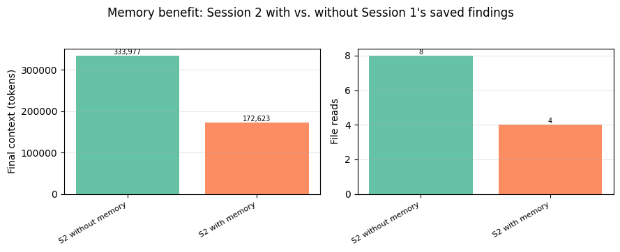

```
Session 2 comparison:
  Without memory: 8 file reads, 2 memory ops, peak ctx 333,977
  With memory:    4 file reads, 3 memory ops, peak ctx 172,623

→ Memory saved 4 file read(s): the agent pulled Session 1's findings from /memories instead of re-reading the source documents.

This comparison shows memory working well because Session 1's notes were comprehensive. If Session 1 had saved sparse or poorly organized notes, Session 2 would fall back to re-reading source documents. Memory's value depends on the agent's judgment about what to write.
```

```python
# Compare: the bar chart shows final context and file reads side by side.
plot_summary_bars(
    {
        "S2 without memory": memory_s2_without,
        "S2 with memory": memory_s2,
    },
    "Memory benefit: Session 2 with vs. without Session 1's saved findings",
)

s2_with_reads = memory_s2.tool_counts.get("read_file", 0)
s2_without_reads = memory_s2_without.tool_counts.get("read_file", 0)
s2_with_mem = memory_s2.tool_counts.get("memory", 0)
s2_without_mem = memory_s2_without.tool_counts.get("memory", 0)

print("Session 2 comparison:")
print(
    f"  Without memory: {s2_without_reads} file reads, {s2_without_mem} memory ops, "
    f"peak ctx {max(t for _, t in memory_s2_without.token_trajectory):,}"
)
print(
    f"  With memory:    {s2_with_reads} file reads, {s2_with_mem} memory ops, "
    f"peak ctx {max(t for _, t in memory_s2.token_trajectory):,}"
)

if s2_with_reads < s2_without_reads:
    saved = s2_without_reads - s2_with_reads
    print(
        f"\n→ Memory saved {saved} file read(s): the agent pulled Session 1's "
        "findings from /memories instead of re-reading the source documents."
    )
elif s2_with_reads == 0 and s2_with_mem > 0:
    print(
        "\n→ Session 2 with memory completed using only /memories; "
        "no source-document re-reads needed."
    )
else:
    print(
        "\n→ Read counts are similar this run. The benefit depends on how "
        "comprehensive Session 1's notes were and how the agent chose to use them."
    )

print(
    "\nThis comparison shows memory working well because Session 1's notes "
    "were comprehensive. If Session 1 had saved sparse or poorly organized "
    "notes, Session 2 would fall back to re-reading source documents. "
    "Memory's value depends on the agent's judgment about what to write."
)
```

### 분석

비교 결과가 이점을 구체적으로 보여 줍니다. 메모리 없는 세션 2는 기댈 것이 없습니다. `/memories`가 비어 있으니 같은 사실을 다시 알아내기 위해 원본 문서로 돌아가야 합니다. 메모리 있는 세션 2는 `/memories`를 읽는 것으로 시작해(자동 주입되는 프로토콜이 이를 기본 첫 행동으로 만듭니다) 세션 1이 저장한 결과를 찾아내고, 모든 원본 문서를 다시 읽는 대신 그것을 바탕으로 종합을 구성할 수 있습니다.

이것이 실제로 구현된 적시 검색입니다. 이전 지식을 전부 첫 프롬프트에 적재하는 대신, 에이전트가 필요할 때 메모리에서 관련된 부분만 꺼내 옵니다. 막대그래프의 파일 읽기 횟수와 최종 컨텍스트가 그 차이를 직접 수치로 보여 줍니다.

메모리가 주는 것은 에이전트가 저장하기로 한 내용에 대한 무손실 충실도와 세션 간 지속성입니다. 반대로 얻지 못하는 것은 세션 내 컨텍스트 증가에 대한 도움이며(세션 1의 최고 컨텍스트는 여전히 높습니다), 읽고 쓸 때마다 도구 호출 부담이 더해집니다. 메모리는 세션 간 문제를 해결하고, 정리와 컴팩션은 세션 내 문제를 해결합니다.

### 메모리를 효과적으로 구현하기

`memory_20250818` 도구는 메모리 우선 확인 프로토콜과 언제든 중단될 수 있다는 전제를 규정하는 시스템 프롬프트를 자동 주입합니다("무엇보다 먼저 항상 메모리 디렉터리를 확인하라... 컨텍스트 윈도는 언제든 초기화될 수 있다"). 기본적인 작동은 이것으로 해결됩니다. 그 이상으로, [메모리 도구 문서](https://platform.claude.com/docs/en/agents-and-tools/tool-use/memory-tool#prompting-guidance)는 모델이 저장하는 내용을 다듬는 여러 방법을 설명합니다.

**주제 안내.** 간단한 시스템 프롬프트 지시로 무엇을 기록할지 유도할 수 있습니다: `"메모리 시스템에는 <주제>와 관련된 정보만 기록하라."` 이 쿡북의 리서치 에이전트라면 "원본 문서 내용이 아니라 비교 결과와 핵심 수치를 저장하라" 정도가 되겠습니다.

**`/memories` 정돈 유지.** 모델이 어수선한 메모리 파일을 만든다면 다음을 덧붙여 보세요: `"메모리 폴더를 수정할 때는 그 내용을 항상 최신이고 일관되며 정돈된 상태로 유지하라. 더는 관련 없는 파일은 이름을 바꾸거나 삭제해도 된다. 꼭 필요하지 않으면 새 파일을 만들지 마라."` 이렇게 하면 세션이 거듭되며 절반쯤 겹치는 메모가 쌓이는 것을 막을 수 있습니다.

**초기화 세션 구조.** 여러 세션에 걸친 작업이라면, 본격적인 작업 전에 메모리 산출물을 준비하는 전용 첫 세션을 돌려 보세요. 진행 로그, 기능 체크리스트, 설정 스크립트 참조 같은 것들입니다. 이후 세션은 그 산출물을 읽는 것으로 시작해 상태를 복구합니다. 이렇게 `/memories`를 미리 채워 두면 세션마다 제각각 정리 방식을 발명하는 대신 일관된 구조 안에서 일하게 됩니다.

**저장소 위생.** 클라이언트 측에서 파일 크기를 추적해 무한정 커지는 것을 막고, 오랫동안 접근되지 않은 메모리 파일을 정리하는 것을 고려하며, 경로 탐색을 검증하세요.

## 요약: 각 기능이 하는 일

| 기능 | 대상 | 내주는 것 | 해결하는 문제 |
| --- | --- | --- | --- |
| **컴팩션** | 현재 윈도의 대화 전체 | 문자 그대로의 세부가 요약으로 압축됨. 지엽적인 사항은 유실될 수 있음 | 세션 내 모든 증가 |
| **정리** | 현재 윈도의 도구 결과 | 오래된 도구 결과가 컨텍스트에서 사라짐(다시 필요하면 재호출해야 함) | 도구 결과 비대화 |
| **메모리** | 윈도 바깥의 외부 저장소 | 도구 호출 부담. 에이전트가 저장하기로 한 것만큼만 쓸모 있음 | 세션 간 지속성 |

아래 차트는 세 가지 단독 실행과 기준점을 나란히 놓은 것입니다. 메모리의 세션 2는 다른 작업(후속 종합)이므로 절대 수치를 다른 것들과 직접 비교할 수는 없습니다. 메모리에서 중요한 것은 위에서 본 세션 2의 메모리 있음 vs. 없음 비교입니다.

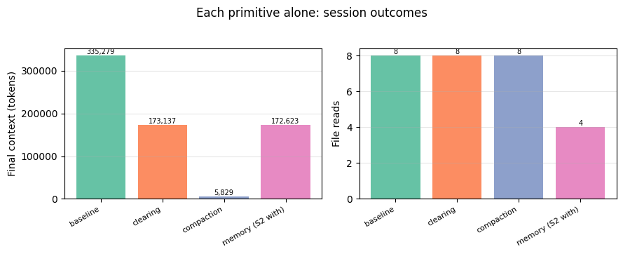

```
Run                  Status             Context events
------------------------------------------------------------
  baseline           completed          none
  clearing           completed          4 clearing
  compaction         completed          1 compaction
  memory (S2 with)   completed          none
```

```python
# Side-by-side view of each primitive's solo run
solo_results = {
    "baseline": baseline,
    "clearing": clearing_run,
    "compaction": compaction_run,
    "memory (S2 with)": memory_s2,
}
plot_summary_bars(solo_results, "Each primitive alone: session outcomes")

# Completion status and events per run
print(f"{'Run':<20} {'Status':<18} {'Context events'}")
print("-" * 60)
for name, res in solo_results.items():
    status = "HIT LIMIT" if res.hit_limit else "completed"
    n_clear = sum(1 for e in res.events if e["kind"] == "clearing")
    n_compact = sum(1 for e in res.events if e["kind"] == "compaction")
    ev_parts = []
    if n_clear:
        ev_parts.append(f"{n_clear} clearing")
    if n_compact:
        ev_parts.append(f"{n_compact} compaction")
    print(f"  {name:<18} {status:<18} {', '.join(ev_parts) if ev_parts else 'none'}")
```

세 기능은 컨텍스트 문제의 서로 다른 조각을 다루므로, 경쟁하는 것이 아니라 조합됩니다. 정리와 컴팩션은 현재 윈도 안의 내용을 관리하고, 메모리는 정보를 윈도 바깥으로 옮겨 세션을 넘어 살아남게 합니다. 어떤 것이 필요한지는 여러분의 워크로드가 실제로 어떤 부분에 부딪히는지에 달려 있습니다.

## 함께 사용하기

세 기능은 컨텍스트 문제의 서로 다른 부분을 겨냥하므로 층층이 쌓을 수 있습니다. [Claude Code](https://code.claude.com/docs/en/memory)는 컴팩션과 함께 [상호 보완적인 두 메모리 시스템](https://code.claude.com/docs/en/memory#claudemd-vs-auto-memory)을 사용하는 실제 사례입니다. `CLAUDE.md` 파일은 개발자가 직접 작성해 소스 관리에 넣는 사용자 정의 지시와 규칙(코딩 표준, 프로젝트 아키텍처, 워크플로)을 담고, 자동 메모리는 Claude가 스스로 기록하는 학습 내용과 패턴(빌드 명령, 디버깅 통찰, 교정에서 알아낸 선호)을 담습니다. 둘 다 Claude Code에 유용한 형태의 메모리입니다.

Claude Code의 설계는 같은 에이전트에서도 메모리가 서로 다른 형태를 띨 수 있음을 보여 줍니다. 하나는 사용자가 쓰고, 다른 하나는 모델이 씁니다. 컴팩션과 정리도 마찬가지입니다. 각각 트리거 임계치, 커스텀 지시, 제외할 도구 같은 설정 항목이 있어 사용 사례에 맞게 동작을 조정할 수 있습니다. 위의 "효과적으로 구현하기" 절에서 다룬 프롬프트와 설정 안내가 중요한 이유가 여기에 있습니다. 기본 동작은 출발점일 뿐이고, 알맞은 설정은 에이전트가 실제로 무엇을 하느냐에 달려 있습니다.

> **`exclude_tools`에 대한 참고**: 정리와 메모리 도구를 함께 쓸 때, 아래 설정에 나오는 `exclude_tools: ["memory"]`는 에이전트의 메모리 읽기·쓰기가 정리되지 않도록 막아 줍니다. 이것이 없으면 에이전트가 방금 저장한 내용을 놓칠 수 있습니다. [메모리 도구 문서](https://platform.claude.com/docs/en/agents-and-tools/tool-use/memory-tool#using-with-context-editing)는 둘을 함께 쓸 때 이를 명시적으로 권장합니다.

아래에서는 세 기능을 모두 켠 채로 리서치 에이전트를 실행하고, 세션 동안 각각이 무슨 일을 하는지 추적합니다.

```python
# Both triggers sit above batch-1's ~167K so the rise is visible. At
# batch-2 (~330K) clearing fires first (keep=6 drops the earliest 3-4
# reads, leaving ~210K) and compaction then fires on what clearing
# left. Tuned for demo visibility, not a production recommendation.
combo_memory = MemoryToolHandler()
COMBO_CLEARING_TRIGGER = 200_000
COMBO_COMPACTION_TRIGGER = 180_000

combo_run = run_research_session(
    """Compare the model organisms in /research/ on lifespan, genetic
tractability, and translational relevance.

Work in two batches, recording a note after each batch before moving on.
Batch 1 (high-throughput): read celegans_review.md, drosophila_review.md,
yeast_review.md, killifish_review.md, then record a note. Batch 2
(low-throughput): read mouse_review.md, zebrafish_review.md,
nmr_review.md, rhesus_review.md, then record a note. Save a comparative
summary to /memories so future sessions can build on it. Finish with a
detailed synthesis.""",
    betas=["context-management-2025-06-27", "compact-2026-01-12"],
    context_management={
        "edits": [
            {
                "type": "clear_tool_uses_20250919",
                "trigger": {"type": "input_tokens", "value": COMBO_CLEARING_TRIGGER},
                "keep": {"type": "tool_uses", "value": 6},
                "clear_at_least": {"type": "input_tokens", "value": 30_000},
                "exclude_tools": ["memory"],
            },
            {
                "type": "compact_20260112",
                "trigger": {"type": "input_tokens", "value": COMBO_COMPACTION_TRIGGER},
            },
        ],
    },
    memory_handler=combo_memory,
    max_turns=20,
    label="all-three",
)
```

```
┌─ [all-three]
│  turn  1  ctx=  2,106
│            memory           view /memories
│  turn  2  ctx=  2,206
│            read_file        /research/celegans_review.md  → ~27,465 tok
│            read_file        /research/drosophila_review.md  → ~27,435 tok
│            read_file        /research/yeast_review.md  → ~27,320 tok
│            read_file        /research/killifish_review.md  → ~27,349 tok
│  turn  3  ctx=167,185
│            memory           create /memories/batch1_notes.md
│  turn  4  ctx=169,938
│            read_file        /research/mouse_review.md  → ~27,390 tok
│            read_file        /research/zebrafish_review.md  → ~27,363 tok
│            read_file        /research/nmr_review.md  → ~27,287 tok
│            read_file        /research/rhesus_review.md  → ~27,285 tok
│  ✂ CLEARING (turn 5): 2 tool results cleared, ~81,993 tokens freed
│  ⊟ COMPACTION (turn 5): ~2,839-token summary replaces prior turns
│  ✂ CLEARING (turn 6): 2 tool results cleared, ~81,810 tokens freed
│  turn  6  ctx=  4,901
│            memory           view /memories/batch1_notes.md  → ~2,370 tok
│  ✂ CLEARING (turn 7): 2 tool results cleared, ~81,683 tokens freed
│  turn  7  ctx=  8,121
│            memory           create /memories/batch2_notes.md
│  ✂ CLEARING (turn 8): 2 tool results cleared, ~81,508 tokens freed
│  turn  8  ctx= 10,524
│            memory           create /memories/comparative_summary.md
│  ✂ CLEARING (turn 9): 2 tool results cleared, ~81,413 tokens freed
│  turn  9  ctx= 12,799
│            search_files     'translational relevance aging pipeline'
│            search_files     'lifespan maximum cohort size intervention'
│  ✂ CLEARING (turn 10): 4 tool results cleared, ~162,379 tokens freed
│  turn 10  ctx= 13,096
│            search_files     'yeast replicative lifespan'
│            search_files     'rhesus macaque caloric restriction'
│  ✂ CLEARING (turn 11): 4 tool results cleared, ~162,371 tokens freed
│  turn 11  ctx= 13,290
│            record_finding   "All 8 model organisms reviewed and compared. Notes..."
│  ✂ CLEARING (turn 12): 4 tool results cleared, ~162,337 tokens freed
│  turn 12  ctx= 13,461
│            memory           str_replace /memories/comparative_summary.md
│  ✂ CLEARING (turn 13): 4 tool results cleared, ~162,331 tokens freed
│  turn 13  ctx= 13,749  (final answer)
└─ completed: 13 turns, peak ctx 169,938, final ctx 13,749, 10 context event(s)
```

```python
# Build a timeline showing when each primitive activated over the session
print("=" * 70)
print("SESSION TIMELINE: all three primitives active")
print("=" * 70)

# Build turn-indexed event markers
clear_turns = {e["turn"] for e in combo_run.events if e["kind"] == "clearing"}
compact_turns = {e["turn"] for e in combo_run.events if e["kind"] == "compaction"}

# Find per-turn memory tool calls by walking messages
mem_call_turns = set()
turn = 0
for msg in combo_run.messages:
    if msg["role"] == "assistant" and isinstance(msg["content"], list):
        turn += 1
        for block in msg["content"]:
            if block.get("type") == "tool_use" and block.get("name") == "memory":
                mem_call_turns.add(turn)

# Print turn-by-turn with markers
for t, ctx in combo_run.token_trajectory:
    markers = []
    if t in clear_turns:
        markers.append("✂ CLEARING")
    if t in compact_turns:
        markers.append("⊟ COMPACTION")
    if t in mem_call_turns:
        markers.append("◇ memory")
    marker_str = "  " + "  ".join(markers) if markers else ""
    print(f"  turn {t:2d}  ctx={ctx:>7,}{marker_str}")

# Summary of what each primitive did
n_clearing = len(clear_turns)
n_compaction = len(compact_turns)
n_memory_calls = combo_run.tool_counts.get("memory", 0)
mem_files = sorted(combo_memory.base.iterdir())

print("\n" + "─" * 70)
print("What each primitive did this session:")
print(f"\n  ✂ Tool-result clearing fired {n_clearing} time(s)")
print(
    f"    → Dropped old tool results to keep context capped at ~{max(t for _, t in combo_run.token_trajectory):,} tokens"
)
print(
    f"    → {combo_run.tool_counts.get('read_file', 0)} file reads total "
    f"(vs baseline's {baseline.tool_counts.get('read_file', 0)}); some were re-fetches after context was reset"
)

if n_compaction > 0:
    print(f"\n  ⊟ Compaction fired {n_compaction} time(s)")
    for ev in combo_run.events:
        if ev["kind"] == "compaction":
            print(
                f"    → At turn {ev['turn']}: replaced prior conversation with ~{count_tokens(ev['summary']):,}-token summary"
            )
else:
    print(
        f"\n  ⊟ Compaction did not fire (clearing kept context below the {COMBO_COMPACTION_TRIGGER:,} trigger)"
    )

print(
    f"\n  ◇ Memory tool called {n_memory_calls} time(s), wrote {len(mem_files)} file(s) to /memories"
)
for f in mem_files:
    content = f.read_text()
    print(f"    → {f.name} (~{count_tokens(content):,} tokens)")
    lines = content.split("\n")
    for line in lines[:6]:
        print(f"        {line}")
    if len(lines) > 6:
        print("        ...")

print("\n" + "─" * 70)
print(
    f"Peak context: {max(t for _, t in combo_run.token_trajectory):,} tokens "
    f"(vs baseline's {max(t for _, t in baseline.token_trajectory):,})"
)
print(f"Final context: {combo_run.token_trajectory[-1][1]:,} tokens")
print(
    f"Session {'completed' if not combo_run.hit_limit else 'HIT LIMIT'} "
    f"in {len(combo_run.token_trajectory)} turns"
)
```

[output not shown]

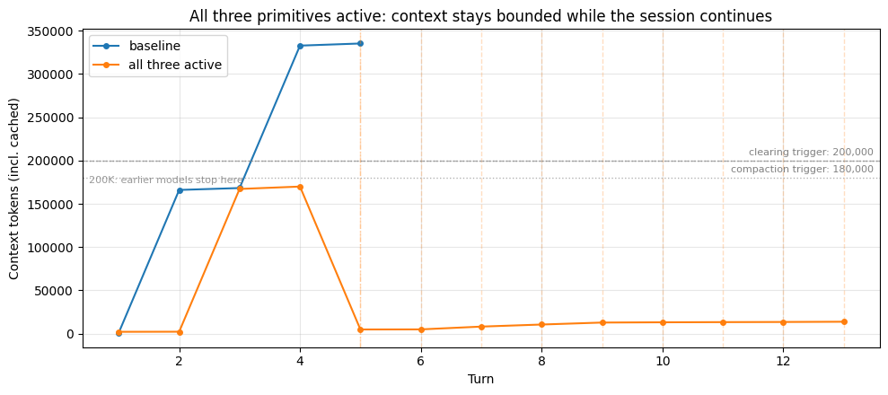

```python
plot_trajectories(
    {"baseline": baseline, "all three active": combo_run},
    "All three primitives active: context stays bounded while the session continues",
    triggers={"clearing": COMBO_CLEARING_TRIGGER, "compaction": COMBO_COMPACTION_TRIGGER},
)
```

### 타임라인이 보여 주는 것

기능들이 일을 유용하게 나눠 갖게 하려면 어느 정도 조정이 필요합니다. 여러분의 워크로드로 값을 실험해 볼 계획을 세우세요.

요점은 세 가지를 모두 돌리면 "최고의" 수치가 나온다는 것이 아닙니다. 각각이 실제로 문제가 발생했을 때 서로 다른 부분을 처리한다는 것입니다. 유용한 질문은 "세 가지를 다 써야 하나?"가 아니라 "내 워크로드가 실제로 겪는 문제는 셋 중 무엇인가?"입니다.

### 어떤 기능을 쓰지 말아야 할 때

모든 워크로드에 모든 도구가 필요한 것은 아닙니다. 일부러 하나를 빼는 경우를 몇 가지 들어 보겠습니다.

- **메모리를 건너뛰세요**, 세션마다 새로 시작하기를 원한다면. 대화가 저마다 독립적이어야 하는 사용자 대면 챗봇에는 세션 간 지속성이 필요 없습니다. 메모리를 더하면 원치 않는 상태를 지고 가게 됩니다.
- **컴팩션을 건너뛰세요**, 세션이 자연히 컨텍스트 한도 아래에 머무를 만큼 짧다면. 컴팩션은 손실이 있으므로(구체적인 세부가 요약되어 사라집니다), 여유 공간이 필요 없다면 아무 대가 없이 충실도만 내주는 셈입니다.
- **정리를 건너뛰세요**, 에이전트가 이전 도구 결과 전문을 정말로 봐야 한다면. 여러 문서의 구절을 나란히 놓고 비교하는 교차 문서 분석 에이전트는 정리된 결과를 제때 다시 가져올 수 없습니다. 정리는 오히려 중복 읽기를 강요하게 됩니다.

## 정리하며, 그리고 다음 단계

### 실험에서 얻은 교훈

리서치 에이전트를 여러 설정으로 돌려 보면 실무적인 교훈 몇 가지가 드러납니다.

**궤적의 모양이 각 도구가 하는 일을 반영합니다.** 정리가 촉발되면 오래된 도구 결과가 제거된 턴에서 계단식 하강이 보이고, 긴 세션에서는 컨텍스트가 다시 트리거를 넘으며 이것이 반복될 수 있습니다. 컴팩션은 촉발될 때마다 더 큰 하강을 만듭니다. 요약이 턴 안의 도구 결과만이 아니라 여러 턴 전체를 대체하기 때문입니다. 이 쿡북의 그래프는 그런 효과를 눈에 보이게 하려는 것으로, 설정을 바꿨을 때 무엇이 달라지는지 구체적으로 볼 수 있습니다. 어떤 도구가 여러분의 워크로드에 맞는지는 별개의 문제이며, 에이전트가 무엇을 해야 하는지에 따라 결정됩니다.

**손실성은 이분법이 아니라 스펙트럼입니다.** 정리는 도구를 다시 호출할 수 있는 한 무손실입니다. 컴팩션은 통제된 방식으로 손실이 있습니다. 요약 프롬프트(기본이든 커스텀이든)가 무엇이 살아남을지를 결정합니다. 메모리는 저장된 것에 대해서는 무손실이지만, 무엇을 저장할지에 대한 에이전트의 판단만큼만 좋습니다. 각 기능이 충실도를 내주는 방식이 다릅니다.

**층을 쌓으면 역량과 복잡도가 같은 비율로 늘어납니다.** 셋을 함께 쓰면 컨텍스트 문제를 더 폭넓게 다루지만, 조정할 항목과 추적할 상호작용도 그만큼 늘어납니다. 기능을 추가하기 전에 던질 유용한 질문은, 그것이 내 워크로드의 어떤 구체적인 문제를 해결하느냐입니다.

**더 큰 컨텍스트 윈도에 대하여.** Sonnet 4.6과 Opus 4.6이 1M 토큰 컨텍스트를 제공하면서 그 여유 공간은 유용해졌습니다. 문자 그대로의 세부를 더 많이 남겨 둘 수 있고, 손실이 있는 연산의 간격도 넓힐 수 있습니다. 하지만 기준점의 컨텍스트 분해에서 보았듯, 1M 모델에서도 작업 집합은 200K 모델과 똑같이 빠르게 낡은 도구 결과로 채워집니다. 차이는 하드 한도가 어디에 있느냐이지 컨텍스트가 얼마나 빨리 쌓이느냐가 아닙니다. 컨텍스트 부패와 프리필 지연 시간은 윈도의 한도가 아니라 윈도에 담긴 양에 비례하므로, 벽이 멀리 있더라도 작업 집합을 가볍게 유지하는 것은 여전히 가치가 있습니다.

### 내 워크로드를 생각해 보기

아래 표는 워크로드 특성과 먼저 시도해 볼 만한 기능을 정리한 것입니다. 정답이 아니라 여러분의 에이전트로 검증해 볼 가설로 받아들이세요. 모든 워크로드에는 표가 담아낼 수 없는 특이점이 있습니다.

| 워크로드가 이렇다면... | 먼저 시도해 볼 것 | 주의할 점 |
| --- | --- | --- |
| 세션이 며칠, 몇 주에 걸침 | 메모리 도구 | 도구 호출 부담. 사실이 바뀌면 메모리가 낡음 |
| 세션을 넘어 사용자 선호를 학습해야 함 | 메모리 도구 | 개인정보·민감정보 정책. 사용자가 마음을 바꾸면 선호가 낡음 |
| 크고 다시 가져올 수 있는 도구 결과 | 정리 | 방금 정리한 것을 에이전트가 다시 읽음. `keep`과 트리거를 조정하세요 |
| 대화가 주된 컨텍스트 | 컴팩션 | 구체적인 수치가 요약되어 사라짐 |
| 다시 가져오기 어려운 도구 결과(일회성 API, 업로드) | 정리보다 컴팩션 | 해당 결과들에 대한 요약 충실도 |
| 세션마다 새로 시작해야 함 | 메모리 건너뛰기 | 원치 않는 세션 간 상태 |
| 세션이 윈도에 한참 못 미침 | 컴팩션 건너뛰기 | 필요 없는 손실 |

### 이 쿡북이 다루지 않은 것

**기본을 넘어선 조정.** 위의 "효과적으로 구현하기" 절들은 각 기능의 출발점을 제공합니다. 다음 단계는 실험입니다. 같은 기능이라도 파라미터와 프롬프트에 따라 사용 사례마다 얻는 가치가 달라집니다. 코딩 에이전트와 리서치 에이전트가 둘 다 컴팩션을 쓸 수 있지만, 한쪽에 잘 맞는 `instructions` 문자열이 다른 쪽에는 맞지 않습니다. 정리 임계치나 `/memories`에 무엇을 쓰도록 안내할지도 마찬가지입니다.

여기서는 테스트 하니스를 만들어 두면 도움이 됩니다. 간단한 예로, 이 쿡북의 에이전트 루프(`run_research_session`)는 `token_trajectory`, `events`, `tool_counts`를 반환합니다. 몇 가지 설정으로 에이전트를 돌려 궤적을 나란히 그려 보고, 여러분에게 중요한 것(작업 품질, 지연 시간, 토큰 지출)을 측정할 수 있습니다.

**인접 기능들.** [프로그래매틱 도구 호출(PTC)](https://www.anthropic.com/engineering/advanced-tool-use)은 모델이 작성한 프로그램 안에서 도구를 실행해 큰 결과가 아예 컨텍스트에 들어오지 않게 하는, 도구 비대화 문제에 대한 또 다른 접근법입니다. [도구 검색](https://www.anthropic.com/engineering/advanced-tool-use)은 도구가 많을 때 도구 정의로 인한 비대화를 줄여 줍니다.

### 관련 읽을거리

[Memory Cookbook](https://platform.claude.com/cookbook/tool-use-memory-cookbook)은 코드 리뷰 에이전트를 통해 메모리 패턴을 더 깊이 다루고, [Compaction Cookbook](https://platform.claude.com/cookbook/tool-use-automatic-context-compaction)은 컴팩션만 따로 다룹니다. 다중 세션 소프트웨어 에이전트에서의 컨텍스트 관리 기법에 대한 상세한 사례 연구는 [장기 실행 에이전트를 위한 효과적인 하니스](https://www.anthropic.com/engineering/effective-harnesses-for-long-running-agents)를 참고하세요.

## 마무리

이 노트북에서는 장기 실행 에이전트를 위한 세 가지 컨텍스트 관리 기능을 살펴봤습니다. 대화 기록을 압축하는 컴팩션, 다시 가져올 수 있는 도구 출력을 버리는 도구 결과 정리, 그리고 세션을 넘어 지식을 유지하는 메모리 도구입니다. 각각이 컨텍스트 문제의 서로 다른 조각을 다룹니다.

여러분의 에이전트에 어떤 기능이 중요한지는 컨텍스트 증가가 실제로 어디서 오는지에 달려 있습니다. 이 쿡북의 설정과 에이전트 루프는 여러분의 워크로드를 여러 설정으로 돌려 보며 무엇이 달라지는지 확인하는 출발점입니다.